# Accelerators Incubators Notebook

# Accelerators Incubators Notebook

## Introduction

We analyze data from the 2500 Accelerators and Incubators Excel file.

## Packages

We install standard packages.

## Options

```r
options(knitr.duplicate.label = "allow")
```

## Functions

```r
source("catchphrases.R")
```

## Data

The data come from a spreadsheet from CB-Insights [1].

```r
library(readxl)
X2_500_Accelerators_Incubators <- read_excel("2,500 Accelerators Incubators.xlsx",
    skip = 2)
View(X2_500_Accelerators_Incubators)
```

## Data Description

```r
glimpse(X2_500_Accelerators_Incubators)
```

```
Rows: 2,658
Columns: 10
$ `Accelerator / Incubator` <chr> "The Spinoff", "Fomocraft Ventures", "Stacks Accelerator", "Brickyard"…
$ Website                   <chr> "https://www.thespinoff.eu/", "http://www.fomocraft.com", "https://sta…
$ Country                   <chr> "Romania", "Hong Kong", NA, "United States", "Spain", "Brazil", "Switz…
$ City                      <chr> "Bucharest", "Hong Kong", NA, "Chattanooga", "Madrid", "São Paulo", "G…
$ Industries                <chr> "Business Development, Education, Incubators", "Blockchain, Financial …
$ `Investment Stage`        <chr> "Non Equity Assistance", "Early Stage Venture, Seed, Venture", "Seed",…
$ Founders                  <chr> NA, NA, "Alex Novosad, Grace Ng, Trevor Owens", "Allan Davis, Barry La…
$ `Founded Date`            <chr> "2021", "2021", "2021", "2021", "2021", "2021", "2021", "2021", "2021"…
$ `Number of Investments`   <dbl> 26, 6, 3, 2, 1, 1, 1, NA, NA, NA, NA, NA, NA, NA, NA, 83, 75, 60, 31, …
$ `Number of Exits`         <dbl> NA, NA, NA, NA, NA, NA, NA, NA, NA, NA, NA, NA, NA, NA, NA, 1, NA, 1, …
```

## Data Wrangling

```r
xai = X2_500_Accelerators_Incubators %>% rename(Name=`Accelerator / Incubator`,
                                                Stage=`Investment Stage`,
                                                FoundDate=`Founded Date`,
                                                NInvestments=`Number of Investments`,
                                                NExits=`Number of Exits`)
xai=mutate(xai, FoundDate=as.numeric(FoundDate))
glimpse(xai)
```

```
Rows: 2,658
Columns: 10
$ Name         <chr> "The Spinoff", "Fomocraft Ventures", "Stacks Accelerator", "Brickyard", "BackFund",…
$ Website      <chr> "https://www.thespinoff.eu/", "http://www.fomocraft.com", "https://stacks.ac/", "ht…
$ Country      <chr> "Romania", "Hong Kong", NA, "United States", "Spain", "Brazil", "Switzerland", "Lux…
$ City         <chr> "Bucharest", "Hong Kong", NA, "Chattanooga", "Madrid", "São Paulo", "Geneva", "Luxe…
$ Industries   <chr> "Business Development, Education, Incubators", "Blockchain, Financial Services, Ven…
$ Stage        <chr> "Non Equity Assistance", "Early Stage Venture, Seed, Venture", "Seed", "Early Stage…
$ Founders     <chr> NA, NA, "Alex Novosad, Grace Ng, Trevor Owens", "Allan Davis, Barry Large, Cameron …
$ FoundDate    <dbl> 2021, 2021, 2021, 2021, 2021, 2021, 2021, 2021, 2021, 2021, 2021, 2021, 2021, 2021,…
$ NInvestments <dbl> 26, 6, 3, 2, 1, 1, 1, NA, NA, NA, NA, NA, NA, NA, NA, 83, 75, 60, 31, 30, 20, 15, 1…
$ NExits       <dbl> NA, NA, NA, NA, NA, NA, NA, NA, NA, NA, NA, NA, NA, NA, NA, 1, NA, 1, NA, NA, NA, N…
```

```r
summary(xai)
```

```
     Name             Website            Country              City            Industries
 Length:2658        Length:2658        Length:2658        Length:2658        Length:2658
 Class :character   Class :character   Class :character   Class :character   Class :character
 Mode  :character   Mode  :character   Mode  :character   Mode  :character   Mode  :character




    Stage             Founders           FoundDate     NInvestments         NExits
 Length:2658        Length:2658        Min.   :1839   Min.   :   1.00   Min.   :  1.00
 Class :character   Class :character   1st Qu.:2010   1st Qu.:   2.00   1st Qu.:  1.00
 Mode  :character   Mode  :character   Median :2014   Median :   7.00   Median :  2.00
                                       Mean   :2012   Mean   :  36.98   Mean   :  7.63
                                       3rd Qu.:2016   3rd Qu.:  25.00   3rd Qu.:  5.50
                                       Max.   :2021   Max.   :4129.00   Max.   :389.00
                                       NA's   :711    NA's   :1072      NA's   :2099
```

```r
cp_length(xai %>% pull(City) %>% unique %>% length,
          "Cities", dataname="xai")
```

```
There are 793 unique Cities in the xai dataset.
```

```r
xai %>% pull(City) %>% unique %>% head
```

```
[1] "Bucharest"   "Hong Kong"   NA            "Chattanooga" "Madrid"      "São Paulo"
```

### Industries

```r
u = xai %>% pull(Industries) %>% unique
cp_length(xai %>% pull(Industries) %>% unique %>% length,
          "Industries", dataname="xai")
```

```
There are 1289 unique Industries in the xai dataset.
```

```r
# data.frame(u)
```

Create the classes by index of the Industries.

```r
Soft = c(1, 3, 4, 6, 8, 13)
Hard = c(2, 5, 9, 10, 11, 12, 15)
Mixed = c(7, 14)

uS = u[Soft];cat("Soft=",uS, "\n")
```

```
Soft= Business Development, Education, Incubators Blockchain, Cryptocurrency NA Angel Investment, Artificial Intelligence, Blockchain, Cyber Security, Finance, Financial Services, FinTech, Hedge Funds, IT Management, Venture Capital Venture Capital Advice, Business Development, Financial Services
```

```r
uM = u[Mixed];cat("Mixed=",uM, "\n")
```

```
Mixed= Finance, Financial Services Financial Services
```

```r
uH = u[Hard];cat("Hard=",uH,"\n")
```

```
Hard= Blockchain, Financial Services, Venture Capital Information Technology, Venture Capital Commercial Real Estate, Real Estate, Real Estate Investment, Venture Capital Finance, Financial Services, Venture Capital Blockchain, Cryptocurrency, Financial Services Finance, Financial Services, Venture …
```

## Examining Data

### Distribution by FoundDate

```r
xai %>% filter(FoundDate<2016) %>% arrange(FoundDate) %>% summarize(Count=n())
```

| Count |
| --- |
| 1320 |

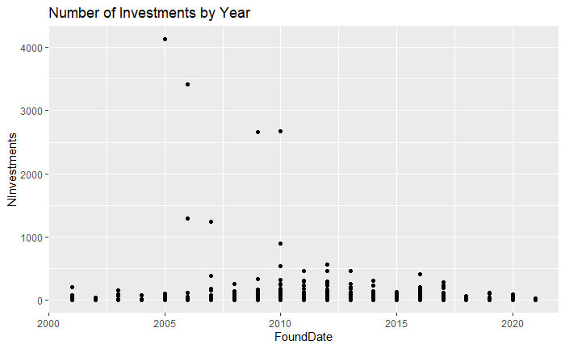

```r
ggplot(xai %>% filter(FoundDate>2000)
       , aes(FoundDate,NInvestments)) +
  geom_point() +
  # geom_smooth(method="lm", se=T) +
  labs(title="Number of Investments by Year" #,
       # subtitle="With linear regression plot"
       )
```

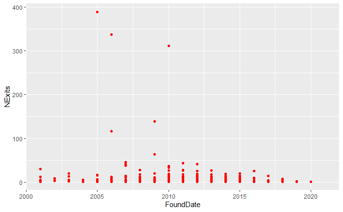

```r
ggplot(xai %>% filter(FoundDate>2000)
       , aes(FoundDate,NExits)) + geom_point(color="red")
```

### Particular Peaks

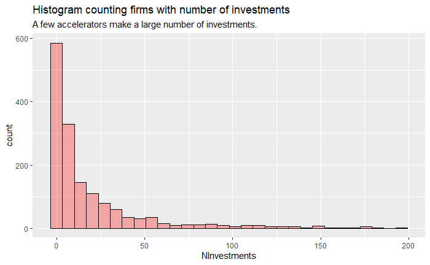

```r
ggplot(xai %>% filter(NInvestments<200), binwidth=1) +
  geom_histogram(aes(NInvestments),color="black", fill="red", alpha=.3) +
  labs(title="Histogram counting firms with number of investments",
       subtitle="A few accelerators make a large number of investments.")
```

[output not shown]

| obs | shortName | NInvestments | FoundDate | NExits | City |
| --- | --- | --- | --- | --- | --- |
| 1700 | Y Combinator | 4129 | 2005 | 389 | Mountain View |
| 1667 | Techstars | 3421 | 2006 | 338 | Boulder |
| 1450 | 500 Startups | 2676 | 2010 | 312 | San Francisco |
| 1544 | MassChallenge | 2659 | 2009 | 139 | Boston |
| 1882 | SOSV | 2127 | 1994 | 53 | Princeton |
| 1668 | Plug and Play Tech C | 1285 | 2006 | 116 | Sunnyvale |
| 1638 | Venture Kick | 1241 | 2007 | 41 | Schlieren |
| 1451 | Start-Up Chile | 896 | 2010 | 26 | Santiago |
| 1179 | Alchemist Accelerato | 563 | 2012 | 41 | San Francisco |
| 1452 | Startupbootcamp | 540 | 2010 | 33 | London |

[output cut: 93 more lines]

## Are there more investments now? And more exits?

```r
# xai %>% arrange(FoundDate)
xai %>% arrange(FoundDate) %>% group_by(FoundDate) %>% summarize(TotalNInvestments=sum(NInvestments),
                                                                 totalNExits=sum(NExits))
```

| FoundDate | TotalNInvestments | totalNExits |
| --- | --- | --- |
| 1839 | NA | NA |
| 1861 | 17 | 1 |
| 1870 | 1 | NA |
| 1876 | 1 | NA |
| 1911 | 2 | 1 |
| 1915 | 1 | 1 |
| 1929 | NA | NA |
| 1942 | NA | NA |
| 1947 | 1 | NA |
| 1950 | NA | NA |

[output cut: 50 more lines]

Most of later accelerators do not report number of investments.

## Parsing by Location

```
Rows: 2,658
Columns: 6
$ CC        <chr> "ALB", "AGO", "ARG", "ARG", "ARG", "ARG", "ARG", "ARG", "ARG", "ARG", "ARG", "ARG", "A…
$ Country   <chr> "Albania", "Angola", "Argentina", "Argentina", "Argentina", "Argentina", "Argentina", …
$ City      <chr> "Tirana", "Luanda", "Buenos Aires", "Buenos Aires", "Buenos Aires", "Buenos Aires", "B…
$ FoundDate <dbl> NA, 2017, 2014, 2015, NA, NA, NA, 2013, NA, 2018, 2016, 2018, 2016, 2014, 2016, 2017, …
$ shortName <chr> "Uplift", "Bantu Makers", "GRID EXPONENTIAL", "Ideas Factory", "Altergaia", "Eklos", "…
$ obs       <int> 2368, 418, 853, 789, 2105, 2425, 2430, 1177, 2221, 288, 623, 182, 513, 896, 611, 451, …
```

| CC | Country | City | FoundDate | shortName | obs |
| --- | --- | --- | --- | --- | --- |
| ALB | Albania | Tirana | NA | Uplift | 2368 |
| AGO | Angola | Luanda | 2017 | Bantu Makers | 418 |
| ARG | Argentina | Buenos Aires | 2014 | GRID EXPONENTIAL | 853 |
| ARG | Argentina | Buenos Aires | 2015 | Ideas Factory | 789 |
| ARG | Argentina | Buenos Aires | NA | Altergaia | 2105 |
| ARG | Argentina | Buenos Aires | NA | Eklos | 2425 |
| ARG | Argentina | Buenos Aires | NA | HacelaRodar | 2430 |
| ARG | Argentina | Córdoba | 2013 | doingLABS | 1177 |
| ARG | Argentina | Córdoba | NA | Eurekalabs | 2221 |
| ARG | Argentina | La Plata | 2018 | Creatribe | 288 |

[output cut: 990 more lines]

### Geocode the City and Country

```r
library(tmaptools)
query=paste(xai$City,xai$Country,sep=",")
query = ifelse(query=="NA,NA",NA,query)
query %>% head(20)
```

```
 [1] "Bucharest,Romania"           "Hong Kong,Hong Kong"         NA
 [4] "Chattanooga,United States"   "Madrid,Spain"                "São Paulo,Brazil"
 [7] "Geneva,Switzerland"          "Luxembourg,Luxembourg"       "Milan,Italy"
[10] "New York,United States"      "Tokyo,Japan"                 "Dhaka,Bangladesh"
[13] "Newton,United States"        "London,United Kingdom"       "Paris,France"
[16] "Xian,China"                  "Mumbai,India"                "Grand Cayman,Cayman Islands"
[19] "Singapore,Singapore"         NA
```

```r
xai= xai %>% mutate(Location=query)
glimpse(xai)
```

```
Rows: 2,658
Columns: 13
$ Name         <chr> "The Spinoff", "Fomocraft Ventures", "Stacks Accelerator", "Brickyard", "BackFund",…
$ Website      <chr> "https://www.thespinoff.eu/", "http://www.fomocraft.com", "https://stacks.ac/", "ht…
$ Country      <chr> "Romania", "Hong Kong", NA, "United States", "Spain", "Brazil", "Switzerland", "Lux…
$ City         <chr> "Bucharest", "Hong Kong", NA, "Chattanooga", "Madrid", "São Paulo", "Geneva", "Luxe…
$ Industries   <chr> "Business Development, Education, Incubators", "Blockchain, Financial Services, Ven…
$ Stage        <chr> "Non Equity Assistance", "Early Stage Venture, Seed, Venture", "Seed", "Early Stage…
$ Founders     <chr> NA, NA, "Alex Novosad, Grace Ng, Trevor Owens", "Allan Davis, Barry Large, Cameron …
$ FoundDate    <dbl> 2021, 2021, 2021, 2021, 2021, 2021, 2021, 2021, 2021, 2021, 2021, 2021, 2021, 2021,…
$ NInvestments <dbl> 26, 6, 3, 2, 1, 1, 1, NA, NA, NA, NA, NA, NA, NA, NA, 83, 75, 60, 31, 30, 20, 15, 1…
$ NExits       <dbl> NA, NA, NA, NA, NA, NA, NA, NA, NA, NA, NA, NA, NA, NA, NA, 1, NA, 1, NA, NA, NA, N…
$ obs          <int> 1, 2, 3, 4, 5, 6, 7, 8, 9, 10, 11, 12, 13, 14, 15, 16, 17, 18, 19, 20, 21, 22, 23, …
$ shortName    <chr> "The Spinoff", "Fomocraft Ventures", "Stacks Accelerator", "Brickyard", "BackFund",…
$ Location     <chr> "Bucharest,Romania", "Hong Kong,Hong Kong", NA, "Chattanooga,United States", "Madri…
```

```r
if(file.exists("xai_gc.RDS")) gc <- readRDS("xai_gc.RDS") else print("No file: run script.")
```

```r
# source("Accelerator Geocode Country.R")
glimpse(gc)
```

```
Rows: 2,658
Columns: 7
$ query   <chr> "Romania", "Hong Kong", NA, "United States", "Spain", "Brazil", "Switzerland", "Luxembou…
$ lat     <dbl> 45.985213, 22.279328, -23.233550, 39.783730, 39.326068, -10.333333, 46.798562, 49.815868…
$ lon     <dbl> 24.685923, 114.162813, 17.323111, -100.445882, -4.837979, -53.200000, 8.231974, 6.129675…
$ lat_min <dbl> 43.6186820, 22.1926504, -28.9694500, -14.7608358, 27.4335426, -33.8689056, 45.8179716, 4…
$ lat_max <dbl> 48.265474, 22.300283, -16.963511, 71.604822, 43.993309, 5.269581, 47.808465, 50.182796, …
$ lon_min <dbl> 20.261996, 114.109880, 11.528038, -180.000000, -18.393684, -73.983063, 5.955911, 5.73570…
$ lon_max <dbl> 30.045426, 114.309050, 25.261729, 180.000000, 4.591888, -28.628965, 10.492294, 6.531248,…
```

```r
xai$Latitude = gc$lat
xai$Longitude = gc$lon
glimpse(xai)
```

```
Rows: 2,658
Columns: 15
$ Name         <chr> "The Spinoff", "Fomocraft Ventures", "Stacks Accelerator", "Brickyard", "BackFund",…
$ Website      <chr> "https://www.thespinoff.eu/", "http://www.fomocraft.com", "https://stacks.ac/", "ht…
$ Country      <chr> "Romania", "Hong Kong", NA, "United States", "Spain", "Brazil", "Switzerland", "Lux…
$ City         <chr> "Bucharest", "Hong Kong", NA, "Chattanooga", "Madrid", "São Paulo", "Geneva", "Luxe…
$ Industries   <chr> "Business Development, Education, Incubators", "Blockchain, Financial Services, Ven…
$ Stage        <chr> "Non Equity Assistance", "Early Stage Venture, Seed, Venture", "Seed", "Early Stage…
$ Founders     <chr> NA, NA, "Alex Novosad, Grace Ng, Trevor Owens", "Allan Davis, Barry Large, Cameron …
$ FoundDate    <dbl> 2021, 2021, 2021, 2021, 2021, 2021, 2021, 2021, 2021, 2021, 2021, 2021, 2021, 2021,…
$ NInvestments <dbl> 26, 6, 3, 2, 1, 1, 1, NA, NA, NA, NA, NA, NA, NA, NA, 83, 75, 60, 31, 30, 20, 15, 1…
$ NExits       <dbl> NA, NA, NA, NA, NA, NA, NA, NA, NA, NA, NA, NA, NA, NA, NA, 1, NA, 1, NA, NA, NA, N…
$ obs          <int> 1, 2, 3, 4, 5, 6, 7, 8, 9, 10, 11, 12, 13, 14, 15, 16, 17, 18, 19, 20, 21, 22, 23, …
$ shortName    <chr> "The Spinoff", "Fomocraft Ventures", "Stacks Accelerator", "Brickyard", "BackFund",…
$ Location     <chr> "Bucharest,Romania", "Hong Kong,Hong Kong", NA, "Chattanooga,United States", "Madri…
$ Latitude     <dbl> 45.985213, 22.279328, -23.233550, 39.783730, 39.326068, -10.333333, 46.798562, 49.8…
$ Longitude    <dbl> 24.685923, 114.162813, 17.323111, -100.445882, -4.837979, -53.200000, 8.231974, 6.1…
```

Use tmap methods.

```r
library(tmap)
data("World")
glimpse(World)

# tmap_mode("view")
#
# tm_shape(World) +
#    tm_polygons("HPI") # sample 5 cities from the metro dataset

# data(metro)
# glimpse(metro)
#
# five_cities <- metro[sample(length(metro), 5), ]
# glimpse(five_cities)
#
# # obtain geocode locations from their long names
# five_cities_geocode <- geocode_OSM(five_cities$name_long, as.sf = TRUE)
# glimpse(five_cities_geocode)
#
# # change to interactive mode
# current.mode <- tmap_mode("view")
#
# # plot metro coordinates in red and geocode coordinates in blue
# # zoom in to see the differences
# tm_shape(five_cities) +
#   tm_dots(col = "blue") +
# tm_shape(five_cities_geocode) +
#   tm_dots(col = "red")
#
# # restore current mode
# tmap_mode(current.mode)
#
# qtm(World) #, text="iso_a3"
#
# tm_shape(World) +
#   tm_dots(col="blue")
```

### Data frame

Grab the Accelerator geocode data as a data frame.

```r
if(file.exists("Accel_df.RDS")) Accel_df1 = readRDS("Accel_df.RDS") else print("No file: run program.")
```

Observe results and correct NA to R’s NA; also check for Palestinian Territory which cannot be found in geocoding.

```r
glimpse(xai)
```

```
Rows: 2,658
Columns: 15
$ Name         <chr> "The Spinoff", "Fomocraft Ventures", "Stacks Accelerator", "Brickyard", "BackFund",…
$ Website      <chr> "https://www.thespinoff.eu/", "http://www.fomocraft.com", "https://stacks.ac/", "ht…
$ Country      <chr> "Romania", "Hong Kong", NA, "United States", "Spain", "Brazil", "Switzerland", "Lux…
$ City         <chr> "Bucharest", "Hong Kong", NA, "Chattanooga", "Madrid", "São Paulo", "Geneva", "Luxe…
$ Industries   <chr> "Business Development, Education, Incubators", "Blockchain, Financial Services, Ven…
$ Stage        <chr> "Non Equity Assistance", "Early Stage Venture, Seed, Venture", "Seed", "Early Stage…
$ Founders     <chr> NA, NA, "Alex Novosad, Grace Ng, Trevor Owens", "Allan Davis, Barry Large, Cameron …
$ FoundDate    <dbl> 2021, 2021, 2021, 2021, 2021, 2021, 2021, 2021, 2021, 2021, 2021, 2021, 2021, 2021,…
$ NInvestments <dbl> 26, 6, 3, 2, 1, 1, 1, NA, NA, NA, NA, NA, NA, NA, NA, 83, 75, 60, 31, 30, 20, 15, 1…
$ NExits       <dbl> NA, NA, NA, NA, NA, NA, NA, NA, NA, NA, NA, NA, NA, NA, NA, 1, NA, 1, NA, NA, NA, N…
$ obs          <int> 1, 2, 3, 4, 5, 6, 7, 8, 9, 10, 11, 12, 13, 14, 15, 16, 17, 18, 19, 20, 21, 22, 23, …
$ shortName    <chr> "The Spinoff", "Fomocraft Ventures", "Stacks Accelerator", "Brickyard", "BackFund",…
$ Location     <chr> "Bucharest,Romania", "Hong Kong,Hong Kong", NA, "Chattanooga,United States", "Madri…
$ Latitude     <dbl> 45.985213, 22.279328, -23.233550, 39.783730, 39.326068, -10.333333, 46.798562, 49.8…
$ Longitude    <dbl> 24.685923, 114.162813, 17.323111, -100.445882, -4.837979, -53.200000, 8.231974, 6.1…
```

```r
glimpse(xai %>% filter(Country != "Palestinian Territory" & !is.na(Country)) )
```

```
Rows: 2,636
Columns: 15
$ Name         <chr> "The Spinoff", "Fomocraft Ventures", "Brickyard", "BackFund", "Velantic Investments…
$ Website      <chr> "https://www.thespinoff.eu/", "http://www.fomocraft.com", "https://www.justlaybrick…
$ Country      <chr> "Romania", "Hong Kong", "United States", "Spain", "Brazil", "Switzerland", "Luxembo…
$ City         <chr> "Bucharest", "Hong Kong", "Chattanooga", "Madrid", "São Paulo", "Geneva", "Luxembou…
$ Industries   <chr> "Business Development, Education, Incubators", "Blockchain, Financial Services, Ven…
$ Stage        <chr> "Non Equity Assistance", "Early Stage Venture, Seed, Venture", "Early Stage Venture…
$ Founders     <chr> NA, NA, "Allan Davis, Barry Large, Cameron Doody, Matt Patterson, Ted Alling", "Adr…
$ FoundDate    <dbl> 2021, 2021, 2021, 2021, 2021, 2021, 2021, 2021, 2021, 2021, 2021, 2021, 2021, 2021,…
$ NInvestments <dbl> 26, 6, 2, 1, 1, 1, NA, NA, NA, NA, NA, NA, NA, NA, 83, 75, 60, 31, 20, 15, 11, 10, …
$ NExits       <dbl> NA, NA, NA, NA, NA, NA, NA, NA, NA, NA, NA, NA, NA, NA, 1, NA, 1, NA, NA, NA, NA, N…
$ obs          <int> 1, 2, 4, 5, 6, 7, 8, 9, 10, 11, 12, 13, 14, 15, 16, 17, 18, 19, 21, 22, 23, 24, 26,…
$ shortName    <chr> "The Spinoff", "Fomocraft Ventures", "Brickyard", "BackFund", "Velantic Investments…
$ Location     <chr> "Bucharest,Romania", "Hong Kong,Hong Kong", "Chattanooga,United States", "Madrid,Sp…
$ Latitude     <dbl> 45.985213, 22.279328, 39.783730, 39.326068, -10.333333, 46.798562, 49.815868, 42.63…
$ Longitude    <dbl> 24.685923, 114.162813, -100.445882, -4.837979, -53.200000, 8.231974, 6.129675, 12.6…
```

```r
xai2=xai %>% filter(Country != "Palestinian Territory" & !is.na(Country))
glimpse(xai2)
```

```
Rows: 2,636
Columns: 15
$ Name         <chr> "The Spinoff", "Fomocraft Ventures", "Brickyard", "BackFund", "Velantic Investments…
$ Website      <chr> "https://www.thespinoff.eu/", "http://www.fomocraft.com", "https://www.justlaybrick…
$ Country      <chr> "Romania", "Hong Kong", "United States", "Spain", "Brazil", "Switzerland", "Luxembo…
$ City         <chr> "Bucharest", "Hong Kong", "Chattanooga", "Madrid", "São Paulo", "Geneva", "Luxembou…
$ Industries   <chr> "Business Development, Education, Incubators", "Blockchain, Financial Services, Ven…
$ Stage        <chr> "Non Equity Assistance", "Early Stage Venture, Seed, Venture", "Early Stage Venture…
$ Founders     <chr> NA, NA, "Allan Davis, Barry Large, Cameron Doody, Matt Patterson, Ted Alling", "Adr…
$ FoundDate    <dbl> 2021, 2021, 2021, 2021, 2021, 2021, 2021, 2021, 2021, 2021, 2021, 2021, 2021, 2021,…
$ NInvestments <dbl> 26, 6, 2, 1, 1, 1, NA, NA, NA, NA, NA, NA, NA, NA, 83, 75, 60, 31, 20, 15, 11, 10, …
$ NExits       <dbl> NA, NA, NA, NA, NA, NA, NA, NA, NA, NA, NA, NA, NA, NA, 1, NA, 1, NA, NA, NA, NA, N…
$ obs          <int> 1, 2, 4, 5, 6, 7, 8, 9, 10, 11, 12, 13, 14, 15, 16, 17, 18, 19, 21, 22, 23, 24, 26,…
$ shortName    <chr> "The Spinoff", "Fomocraft Ventures", "Brickyard", "BackFund", "Velantic Investments…
$ Location     <chr> "Bucharest,Romania", "Hong Kong,Hong Kong", "Chattanooga,United States", "Madrid,Sp…
$ Latitude     <dbl> 45.985213, 22.279328, 39.783730, 39.326068, -10.333333, 46.798562, 49.815868, 42.63…
$ Longitude    <dbl> 24.685923, 114.162813, -100.445882, -4.837979, -53.200000, 8.231974, 6.129675, 12.6…
```

Check out Accel df size and filter the NAs.

```r
glimpse(Accel_df1)
glimpse(Accel_df1 %>% filter(is.na(query)))
```

Make a new df omitting the NAs.

```r
summary(Accel_df2)
```

```
    query                lat              lon              lat_min          lat_max
 Length:2636        Min.   :-42.40   Min.   :-157.717   Min.   :-42.42   Min.   :-42.38
 Class :character   1st Qu.: 32.78   1st Qu.: -84.390   1st Qu.: 32.03   1st Qu.: 33.02
 Mode  :character   Median : 39.96   Median :  -1.554   Median : 39.85   Median : 40.12
                    Mean   : 35.16   Mean   : -20.486   Mean   : 34.79   Mean   : 35.34
                    3rd Qu.: 47.60   3rd Qu.:  19.316   3rd Qu.: 47.42   3rd Qu.: 47.72
                    Max.   : 65.01   Max.   : 176.168   Max.   : 64.84   Max.   : 65.56
    lon_min            lon_max
 Min.   :-157.954   Min.   :-157.649
 1st Qu.: -84.551   1st Qu.: -84.290
 Median :  -1.669   Median :  -1.479
 Mean   : -20.768   Mean   : -20.073
 3rd Qu.:  19.215   3rd Qu.:  19.411
 Max.   : 176.008   Max.   : 176.328
```

These two should match in obs number. Add the obs and the shortName to the Accel df.

```r
Accel_df3 = Accel_df2 %>%
 mutate(obs=xai %>% filter(Country != "Palestinian Territory" & !is.na(Country)) %>% pull(obs),
  name=xai %>% filter(Country != "Palestinian Territory" & !is.na(Country)) %>% pull(shortName),
  country=xai %>% filter(Country != "Palestinian Territory" & !is.na(Country)) %>% pull(Country),
  industries=xai %>%
    filter(Country != "Palestinian Territory" & !is.na(Country)) %>% pull(Industries))
glimpse(Accel_df3)
```

```
Rows: 2,636
Columns: 11
$ query      <chr> "Bucharest,Romania", "Hong Kong,Hong Kong", "Chattanooga,United States", "M…
$ lat        <dbl> 44.436141, 22.279328, 35.045722, 40.416705, -23.550651, 46.201756, 49.61127…
$ lon        <dbl> 26.1027202, 114.1628131, -85.3094883, -3.7035825, -46.6333824, 6.1466014, 6…
$ lat_min    <dbl> 44.334247, 22.192650, 34.885722, 40.256705, -23.710651, 46.041756, 49.56098…
$ lat_max    <dbl> 44.541396, 22.300283, 35.205722, 40.576705, -23.390651, 46.361756, 49.65486…
$ lon_min    <dbl> 25.9666745, 114.1098795, -85.4694883, -3.8635825, -46.7933824, 5.9866014, 6…
$ lon_max    <dbl> 26.2255768, 114.3090495, -85.1494883, -3.5435825, -46.4733824, 6.3066014, 6…
$ obs        <int> 1, 2, 4, 5, 6, 7, 8, 9, 10, 11, 12, 13, 14, 15, 16, 17, 18, 19, 21, 22, 23,…
$ name       <chr> "The Spinoff", "Fomocraft Ventures", "Brickyard", "BackFund", "Velantic Inv…
$ country    <chr> "Romania", "Hong Kong", "United States", "Spain", "Brazil", "Switzerland", …
$ industries <chr> "Business Development, Education, Incubators", "Blockchain, Financial Servi…
```

There are 2636 observations. Check that we have the correct names, matching xai names.

```r
any(Accel_df3$obs != xai2$obs)
```

```
[1] FALSE
```

```r
any(Accel_df3$shortName != xai2$shortName)
```

```
[1] FALSE
```

### Shapefile

Grab the Accelerator geocode data as a shapefile.

```r
if(file.exists("Accel_sf.shp")) Accel_in = sf::st_read("Accel_sf.shp") else print("No file: run program.")
glimpse(Accel_in)
summary(Accel_in)
Accel_in$query=gsub("Unknown[0-9]*","NA",Accel_in$query)
Accel_in$query[Accel_in$query=="NA"] = NA
glimpse(Accel_in)
```

If the data does not exist run the script to geocode it.

```r
# source("Accelerator Geocodes Notebook.R")
```

Make a point map.

```r
library(tmap)
tmap_mode(mode="view")
acc=tm_shape(Accel_in) +
  tm_dots(col="blue")
acc
```

Incubators and Accelerators are concentrated in the US and Europe. Netherlands and Germany as well as the UK have the highest concentration in Europe.

They are more diffuse in the US, with the large western concentrations in the LA and San Diego area, the San Francisco area and to a small extent in the Seattle area. On the East coast, concentrations occur on the New York - Boston big city axis. Chicago and the DC area have small concentrations. Atlanta, Dallas, Salt Lake City, Phoenix, Minneapolis, and the Colorado area also have small groups.

It’s clear the locations are a product of larger concentrations of people.

Now we overlay the accelerators with ports of the world.

```r
# library(sf)
pshape=sf::st_read("Ports features.json")
glimpse(pshape)
pshape %>% pull(prtsize) %>% unique
```

Change the port shape file with a factor for the various port sizes.

```r
pshape = pshape %>% mutate( prtsize2 = case_when(
  prtsize == "Very Small" ~ 1,
  prtsize == "Unknown" ~ 0,
  prtsize == "Small" | prtsize =="small" ~ 2,
  prtsize == "Medium" ~ 3,
  prtsize == "Large" ~ 4,
  prtsize == "Big" ~ 5,
  is.na(prtsize) ~ 0,
  TRUE ~ 0
  )
)
glimpse(pshape)


pshape_map = pshape %>% filter(prtsize2==0|prtsize2>2)
tm_basemap("OpenStreetMap") +
  tm_shape(pshape_map) +
  tm_dots(col="blue")

qtm(pshape %>% filter(prtsize2>2), dots.col="blue")
```

These are not all ports. Many large ones are omitted, probably because they are not open access.

Try another source [5] https://msi.nga.mil/Publications/WPI

```r
wpi=sf::st_read("WPI_Shapefile/WPI.dbf")
glimpse(wpi)
```

```r
wpi %>% pull(HARBORSIZE) %>% unique()
wpi %>% pull(HARBORTYPE) %>% unique()
wpi %>% pull(CHAN_DEPTH) %>% unique() %>% sort()
wpi %>% as.tibble %>%
  select(PORT_NAME,COUNTRY, LATITUDE, LONGITUDE, CHAN_DEPTH, MAX_VESSEL) %>%
  arrange(CHAN_DEPTH, PORT_NAME) %>%
  group_by(PORT_NAME,MAX_VESSEL) %>%
  filter(COUNTRY=="US", MAX_VESSEL=="L")
```

Select the large and medium size ports and plot them with the accelerators.

```r
wpi_large = wpi %>% filter(HARBORSIZE=="L" | HARBORSIZE=="M" )
glimpse(wpi_large)

gm = tm_shape(wpi_large, bbox="Europe") +
  tm_dots(col="blue") +
  tm_shape(Accel_in, bbox="Europe", is.master=FALSE) +
  tm_dots(col="red", size=0.01) +
  tm_layout("Accelerators and Ports")
gm
# tmap_save(gm, "Accelerators and Ports.html", selfcontained=TRUE)
```

## Measuring Relative Spatial Position I

We will use the `spatialrisk` package to find the number of incubators inside a circle of given diameter for each port. This package has code written in C++ and so it runs very fast.

```r
library(spatialrisk)
```

We use the points_in_circle function [4] which uses the haversine formula to calculate observations within a radius from a center point. The center point is selected as the port. Here is an example with the first large port.

### One Large Port - Los Angeles

Find a large port to serve as focus.

```r
glimpse(wpi_large)
wtarget=wpi_large %>% as.tibble %>% filter(HARBORSIZE=="L" & PORT_NAME=="LOS ANGELES") %>%
  select(INDEX_NO, PORT_NAME, LONGITUDE, LATITUDE)
wtarget
```

Determine accelerators inside a circle of radius 100000 meters of Los Angeles. 100000 meters is about 100000/1609 or 62.150404 miles.

| INDEX_NO | PORT_NAME | LONGITUDE | LATITUDE | query | lat | lon | lat_min | lat_max | lon_min | lon_max | obs | name | distance_m |
| --- | --- | --- | --- | --- | --- | --- | --- | --- | --- | --- | --- | --- | --- |
| 16080 | LOS ANGELES | -118.25 | 33.75 | Long Beach,United States | 33.76902 | -118.1916 | 33.69058 | 33.88560 | -118.2490 | -118.0633 | 967 | Riversands Incubatio | 5804.263 |
| 16080 | LOS ANGELES | -118.25 | 33.75 | Long Beach,United States | 33.76902 | -118.1916 | 33.69058 | 33.88560 | -118.2490 | -118.0633 | 2232 | Imprint Lab | 5804.263 |
| 16080 | LOS ANGELES | -118.25 | 33.75 | Artesia,United States | 33.86902 | -118.0796 | 33.85341 | 33.88038 | -118.0913 | -118.0689 | 1138 | GenerationS | 20588.724 |
| 16080 | LOS ANGELES | -118.25 | 33.75 | La Palma,United States | 33.84640 | -118.0467 | 33.80640 | 33.88640 | -118.0867 | -118.0067 | 1139 | Incuvation Labs LLC | 21650.639 |
| 16080 | LOS ANGELES | -118.25 | 33.75 | Cerritos,United States | 33.86443 | -118.0539 | 33.84586 | 33.88791 | -118.1087 | -118.0287 | 1318 | Mila Venture Group | 22162.210 |
| 16080 | LOS ANGELES | -118.25 | 33.75 | El Segundo,United States | 33.91703 | -118.4156 | 33.88818 | 33.93126 | -118.4987 | -118.3745 | 1576 | L.A. Libations | 24089.286 |

## All Ports

This looks very promising. Look for all Accelerators within a radius of the Large ports.

```r
wtarget=wpi_large %>% as.tibble %>% filter(HARBORSIZE=="L") %>%
  select(INDEX_NO, PORT_NAME, LONGITUDE, LATITUDE, COUNTRY)
radius=20000
targets= c(1:nrow(wtarget))
ball_list=list()
ball_specs=list()
for (i in targets) {
  w=wtarget[i,]
  ans = purrr::map2_dfr(w$LONGITUDE, w$LATITUDE,
                         ~spatialrisk::points_in_circle(data=Accel_df3 , .x, .y,
                                                        lon, lat,
                                                        radius = radius))
  ans_count=nrow(ans)
  ball_list[w$PORT_NAME] = list(count=ans_count)
  if(ans_count>0) {
    # glimpse(ans)
    ans_short = ans %>% select(query, lon, lat, obs, name, distance_m)
    res = cbind(w, ans_short)
    # print(res)
    res_count = nrow(res)
    res_which = res$obs
    res_name = res$name
    res_port = w$PORT_NAME
    res_pindex = w$INDEX_NO
    ball_specs[w$PORT_NAME] = list(nearest=res)
  }
}
```

Look at results.

```r
# length(ball_list)
ball_frame = data.frame(Port=wtarget[targets,"PORT_NAME"],
                        PortID=wtarget[targets,"INDEX_NO"],
                        Country=wtarget[targets,"COUNTRY"],
                        Count=matrix(unlist(ball_list), nrow=length(ball_list), byrow=TRUE))
ball_frame
```

| PORT_NAME | INDEX_NO | COUNTRY | Count |
| --- | --- | --- | --- |
| AS SUWAYS | 48040 | EG | 0 |
| BELFAST | 33770 | GB | 0 |
| PUSAN | 60390 | KR | 1 |
| QINGDAO GANG | 60140 | CN | 0 |
| KASIM TERMINAL | 53045 | ID | 0 |
| NAPOLI | 39960 | IT | 1 |
| PENNINGTON OIL TERMINAL | 46200 | NG | 0 |
| TALLINN | 28480 | EE | 9 |
| RIGA | 28610 | LV | 3 |
| TIANJIN XIN GANG | 60190 | CN | 0 |

[output cut: 150 more lines]

```r
ball_frame %>% arrange(desc(Count), PORT_NAME)
```

| PORT_NAME | INDEX_NO | COUNTRY | Count |
| --- | --- | --- | --- |
| BROOKLYN | 7630 | US | 121 |
| NEW YORK CITY | 7640 | US | 121 |
| LONDON | 31470 | GB | 116 |
| OAKLAND | 16340 | US | 104 |
| SAN FRANCISCO | 16300 | US | 104 |
| JOHOR | 49982 | MY | 43 |
| JURONG ISLAND | 50017 | SG | 43 |
| KEPPEL - (EAST SINGAPORE) | 50000 | SG | 43 |
| TOKYO KO | 61380 | JP | 40 |
| BOSTON | 7250 | US | 39 |

[output cut: 150 more lines]

```r
ball_frame %>% arrange(desc(Count), PORT_NAME) %>% group_by(Count) %>%
  summarize(number=n()) %>% arrange(desc(Count))
```

| Count | number |
| --- | --- |
| 121 | 2 |
| 116 | 1 |
| 104 | 2 |
| 43 | 3 |
| 40 | 1 |
| 39 | 1 |
| 30 | 1 |
| 27 | 1 |
| 25 | 1 |
| 24 | 1 |

[output cut: 18 more lines]

```r
# ball_specs
```

## Histograms

```r
n=max(ball_frame$Count)
r=32
q=scales::oob_censor(ball_frame$Count, range=c(0,r))
xq=ball_frame %>% filter(is.na(q))
knitr::kable(xq %>% arrange(desc(Count)), caption="Ports out of range")
```

Ports out of range

| PORT_NAME | INDEX_NO | COUNTRY | Count |
| --- | --- | --- | --- |
| BROOKLYN | 7630 | US | 121 |
| NEW YORK CITY | 7640 | US | 121 |
| LONDON | 31470 | GB | 116 |
| SAN FRANCISCO | 16300 | US | 104 |
| OAKLAND | 16340 | US | 104 |
| JOHOR | 49982 | MY | 43 |
| KEPPEL - (EAST SINGAPORE) | 50000 | SG | 43 |
| JURONG ISLAND | 50017 | SG | 43 |
| TOKYO KO | 61380 | JP | 40 |
| BOSTON | 7250 | US | 39 |

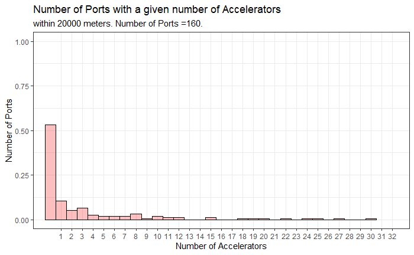

```r
ggplot() +
  geom_histogram(aes(q, y=..density..),
                 color="black", fill="red2", alpha=.25,
                 binwidth=1, boundary=-0.5) +
  scale_x_continuous(breaks=1:min(n,r), minor_breaks=NULL) +
  coord_cartesian(xlim=c(0,min(n,r)), ylim=c(0,1)) +
  theme(panel.grid.minor.x = element_blank()) +
  labs(x="Number of Accelerators", y="Number of Ports",
       title="Number of Ports with a given number of Accelerators",
       subtitle=paste0("within ",radius, " meters.", " Number of Ports =", length(q), ".")) +
  theme_bw() +
  geom_text(aes(x=r-3,y=2,label=paste0(xq$PORT_NAME,"\n",xq$Count)))
```

## Histograms of Port Countries

### US Ports

A histogram of US Ports.

Set the country and extract the ports with counts.

```r
ctry="US"
b_f = ball_frame %>% filter(COUNTRY==ctry)
# glimpse(b_f)

xq=b_f %>% filter(is.na(Count))
# glimpse(xq)
if(nrow(xq)>0)
  xq %>% arrange(desc(Count)) else
    print(paste0("No ",ctry, " ports out of range."))
```

```
[1] "No US ports out of range."
```

```r
yq=b_f %>% filter(!is.na(Count))
if(nrow(yq)>0)
  yq %>% arrange(desc(Count)) else
    print(paste0("No ",ctry, " ports in range."))
```

| PORT_NAME | INDEX_NO | COUNTRY | Count |
| --- | --- | --- | --- |
| BROOKLYN | 7630 | US | 121 |
| NEW YORK CITY | 7640 | US | 121 |
| SAN FRANCISCO | 16300 | US | 104 |
| OAKLAND | 16340 | US | 104 |
| BOSTON | 7250 | US | 39 |
| SEATTLE | 17730 | US | 27 |
| PORTLAND | 16940 | US | 15 |
| PHILADELPHIA | 8110 | US | 11 |
| CHESTER | 8080 | US | 10 |
| TRI-CITY PORT | 8890 | US | 8 |

[output cut: 11 more lines]

Set plot parameters and draw histogram. Choose r=40 to leave out New York-Brooklyn and San Francisco-Oakland.

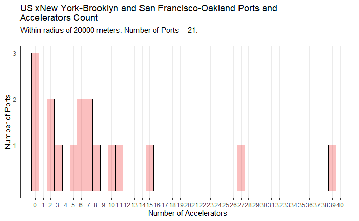

```r
h = yq %>% arrange(desc(Count)) %>% group_by(Count) %>%
  summarize(nlevel=n()) %>% pull(nlevel) %>% max()
n=max(b_f$Count)
# this parameter sets range of counts
r= 40 # max(yq$Count)

q=scales::oob_censor(b_f$Count, range=c(0,r))

p1=ggplot() +
  geom_histogram(aes(q), # , y=..density..
                 color="black", fill="red2", alpha=.25,
                 binwidth=1, boundary=-0.5) +
  scale_x_continuous(breaks=0:min(n,r), minor_breaks=NULL) +
  scale_y_continuous(breaks=1:h, minor_breaks=NULL) +
  coord_cartesian(xlim=c(0,min(n,r)), ylim=c(0,h)) +
  theme(panel.grid.minor.x = element_blank()) +
  labs(x="Number of Accelerators", y="Number of Ports",
       title=paste0("US xNew York-Brooklyn and San Francisco-Oakland",
       " Ports and\nAccelerators Count"),
       subtitle=paste0("Within radius of ",radius, " meters.",
                       " Number of Ports = ", length(q), ".\n")) +
  theme_bw()

p2=ggplot() +
  geom_histogram(aes(q, y=..density..), #
                 color="black", fill="red2", alpha=.25,
                 binwidth=1, boundary=-0.5) +
  scale_x_continuous(breaks=0:min(n,r), minor_breaks=NULL) +
  scale_y_continuous(n.breaks=10) +
  coord_cartesian(xlim=c(0,min(n,r)), ylim=c(0,1)) +
  theme(panel.grid.minor.x = element_blank()) +
  labs(x="Number of Accelerators", y="Fraction of Ports",
       title=paste0("US xNew York-Brooklyn and San Francisco-Oakland",
       " Ports and \nAccelerator Density"),
       subtitle=paste0("Fraction ","Within radius of ",radius, " meters.",
                       " Number of Ports = ", length(q), ".\n",
                       "One port contributes density of ",round(1/length(q),5))) +
  theme_bw()
p1
```

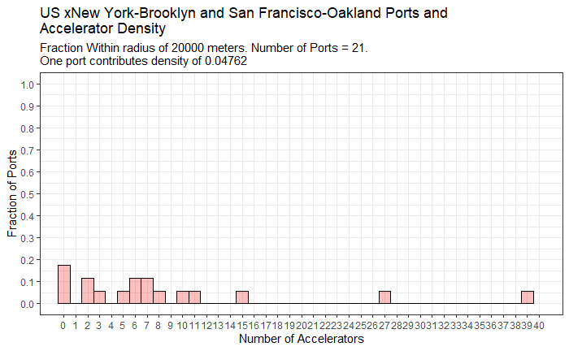

```r
p2
```

### GB Ports

A histogram of UK (coded as GB) Ports.

Set the country and extract the ports with counts.

```r
ctry="GB"
b_f = ball_frame %>% filter(COUNTRY==ctry)
# glimpse(b_f)

xq=b_f %>% filter(is.na(Count))
# glimpse(xq)
if(nrow(xq)>0)
  xq %>% arrange(desc(Count)) else
    print(paste0("No ",ctry, " ports out of range."))
```

```
[1] "No GB ports out of range."
```

```r
yq=b_f %>% filter(!is.na(Count))
if(nrow(yq)>0)
  yq %>% arrange(desc(Count)) else
    print(paste0("No ",ctry, " ports in range."))
```

| PORT_NAME | INDEX_NO | COUNTRY | Count |
| --- | --- | --- | --- |
| LONDON | 31470 | GB | 116 |
| MANCHESTER | 34700 | GB | 3 |
| SOUTHAMPTON | 35580 | GB | 1 |
| LIVERPOOL | 34690 | GB | 1 |
| DUNDEE | 32170 | GB | 1 |
| TEESPORT | 31720 | GB | 1 |
| BELFAST | 33770 | GB | 0 |

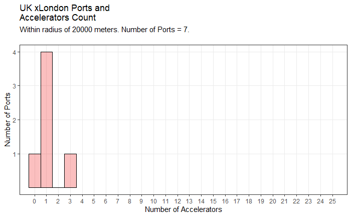

```r
h = yq %>% arrange(desc(Count)) %>% group_by(Count) %>%
  summarize(nlevel=n()) %>% pull(nlevel) %>% max()
n=max(b_f$Count)
# this parameter sets range of counts
r= 25 # max(yq$Count)

q=scales::oob_censor(b_f$Count, range=c(0,r))

p1=ggplot() +
  geom_histogram(aes(q), # , y=..density..
                 color="black", fill="red2", alpha=.25,
                 binwidth=1, boundary=-0.5) +
  scale_x_continuous(breaks=0:min(n,r), minor_breaks=NULL) +
  scale_y_continuous(breaks=1:h, minor_breaks=NULL) +
  coord_cartesian(xlim=c(0,min(n,r)), ylim=c(0,h)) +
  theme(panel.grid.minor.x = element_blank()) +
  labs(x="Number of Accelerators", y="Number of Ports",
       title=paste0("UK xLondon",
       " Ports and\nAccelerators Count"),
       subtitle=paste0("Within radius of ",radius, " meters.",
                       " Number of Ports = ", length(q), ".\n")) +
  theme_bw()

p2=ggplot() +
  geom_histogram(aes(q, y=..density..), #
                 color="black", fill="red2", alpha=.25,
                 binwidth=1, boundary=-0.5) +
  scale_x_continuous(breaks=0:min(n,r), minor_breaks=NULL) +
  scale_y_continuous(n.breaks=10) +
  coord_cartesian(xlim=c(0,min(n,r)), ylim=c(0,1)) +
  theme(panel.grid.minor.x = element_blank()) +
  labs(x="Number of Accelerators", y="Fraction of Ports",
       title=paste0("UK xLondon",
       " Ports and \nAccelerator Density"),
       subtitle=paste0("Fraction ","Within radius of ",radius, " meters.",
                       " Number of Ports = ", length(q), ".\n",
                       "One port contributes density of ",round(1/length(q),5))) +
  theme_bw()
p1
```

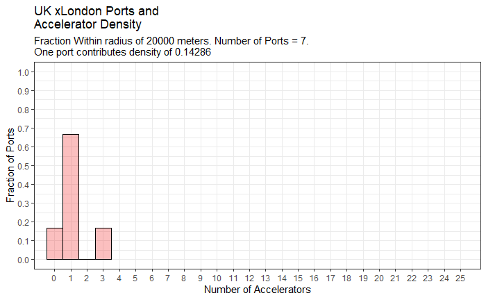

```r
p2
```

### NL Ports

A histogram of Netherlands (coded as NL) Ports.

Set the country and extract the ports with counts.

```r
ctry="NL"
b_f = ball_frame %>% filter(COUNTRY==ctry)
# glimpse(b_f)

xq=b_f %>% filter(is.na(Count))
# glimpse(xq)
if(nrow(xq)>0)
  xq %>% arrange(desc(Count)) else
    print(paste0("No ",ctry, " ports out of range."))
```

```
[1] "No NL ports out of range."
```

```r
yq=b_f %>% filter(!is.na(Count))
if(nrow(yq)>0)
  yq %>% arrange(desc(Count)) else
    print(paste0("No ",ctry, " ports in range."))
```

| PORT_NAME | INDEX_NO | COUNTRY | Count |
| --- | --- | --- | --- |
| AMSTERDAM | 31060 | NL | 19 |
| ROTTERDAM | 31140 | NL | 4 |

Set plot parameters and draw histogram. Amsterdam has 19, Rotterdam 4

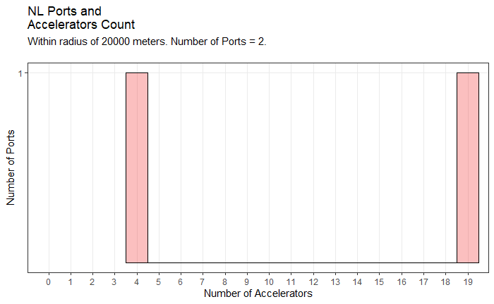

```r
h = yq %>% arrange(desc(Count)) %>% group_by(Count) %>%
  summarize(nlevel=n()) %>% pull(nlevel) %>% max()
n=max(b_f$Count)
# this parameter sets range of counts
r= 20 # max(yq$Count)

q=scales::oob_censor(b_f$Count, range=c(0,r))

p1=ggplot() +
  geom_histogram(aes(q), # , y=..density..
                 color="black", fill="red2", alpha=.25,
                 binwidth=1, boundary=-0.5) +
  scale_x_continuous(breaks=0:min(n,r), minor_breaks=NULL) +
  scale_y_continuous(breaks=1:h, minor_breaks=NULL) +
  coord_cartesian(xlim=c(0,min(n,r)), ylim=c(0,h)) +
  theme(panel.grid.minor.x = element_blank()) +
  labs(x="Number of Accelerators", y="Number of Ports",
       title=paste0("NL",
       " Ports and\nAccelerators Count"),
       subtitle=paste0("Within radius of ",radius, " meters.",
                       " Number of Ports = ", length(q), ".\n")) +
  theme_bw()

p2=ggplot() +
  geom_histogram(aes(q, y=..density..), #
                 color="black", fill="red2", alpha=.25,
                 binwidth=1, boundary=-0.5) +
  scale_x_continuous(breaks=0:min(n,r), minor_breaks=NULL) +
  scale_y_continuous(n.breaks=10) +
  coord_cartesian(xlim=c(0,min(n,r)), ylim=c(0,1)) +
  theme(panel.grid.minor.x = element_blank()) +
  labs(x="Number of Accelerators", y="Fraction of Ports",
       title=paste0("NL",
       " Ports and \nAccelerator Density"),
       subtitle=paste0("Fraction ","Within radius of ",radius, " meters.",
                       " Number of Ports = ", length(q), ".\n",
                       "One port contributes density of ",round(1/length(q),5))) +
  theme_bw()
p1
```

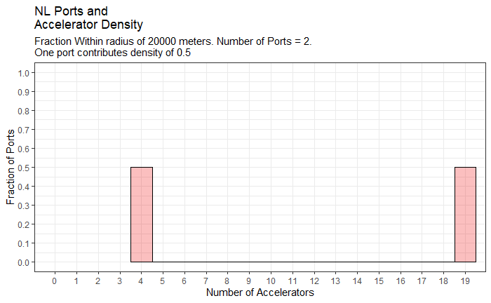

```r
p2
```

### CN Ports

A histogram of China (coded as CN) Ports.

Set the country and extract the ports with counts.

```r
countrycode::countryname("Hong Kong", destination="iso2c")
```

```
[1] "HK"
```

```r
ctry=c("CN","HK")
b_f = ball_frame %>% filter(COUNTRY %in% ctry)
# glimpse(b_f)

xq=b_f %>% filter(is.na(Count))
# glimpse(xq)
if(nrow(xq)>0)
  xq %>% arrange(desc(Count)) else
    print(paste0("No ",ctry, " ports out of range."))
```

```
[1] "No CN ports out of range." "No HK ports out of range."
```

```r
yq=b_f %>% filter(!is.na(Count))
if(nrow(yq)>0)
  yq %>% arrange(desc(Count)) else
    print(paste0("No ",ctry, " ports in range."))
```

| PORT_NAME | INDEX_NO | COUNTRY | Count |
| --- | --- | --- | --- |
| HONG KONG | 57840 | HK | 24 |
| SHANGHAI | 59970 | CN | 8 |
| DALIAN | 60250 | CN | 1 |
| QINGDAO GANG | 60140 | CN | 0 |
| TIANJIN XIN GANG | 60190 | CN | 0 |
| LON SHUI TERMINAL | 57775 | CN | 0 |

Set plot parameters and draw histogram. Hong Kong has 24, Shanghai has 8, Dalian 1, and the rest none.

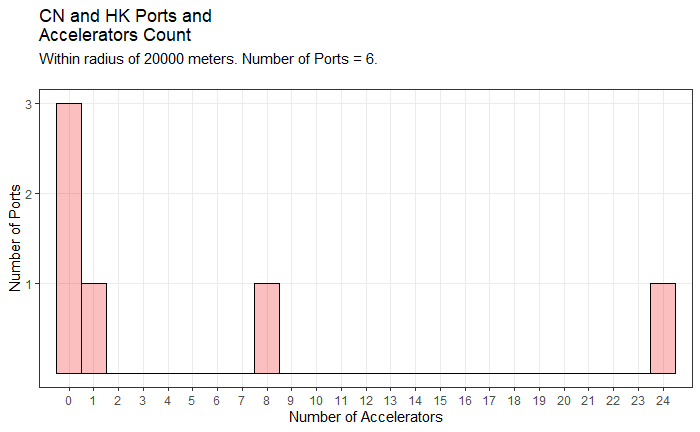

```r
h = yq %>% arrange(desc(Count)) %>% group_by(Count) %>%
  summarize(nlevel=n()) %>% pull(nlevel) %>% max()
n=max(b_f$Count)
# this parameter sets range of counts
r= max(yq$Count)

q=scales::oob_censor(b_f$Count, range=c(0,r))

p1=ggplot() +
  geom_histogram(aes(q), # , y=..density..
                 color="black", fill="red2", alpha=.25,
                 binwidth=1, boundary=-0.5) +
  scale_x_continuous(breaks=0:min(n,r), minor_breaks=NULL) +
  scale_y_continuous(breaks=1:h, minor_breaks=NULL) +
  coord_cartesian(xlim=c(0,min(n,r)), ylim=c(0,h)) +
  theme(panel.grid.minor.x = element_blank()) +
  labs(x="Number of Accelerators", y="Number of Ports",
       title=paste0("CN and HK",
       " Ports and\nAccelerators Count"),
       subtitle=paste0("Within radius of ",radius, " meters.",
                       " Number of Ports = ", length(q), ".\n")) +
  theme_bw()

p2=ggplot() +
  geom_histogram(aes(q, y=..density..), #
                 color="black", fill="red2", alpha=.25,
                 binwidth=1, boundary=-0.5) +
  scale_x_continuous(breaks=0:min(n,r), minor_breaks=NULL) +
  scale_y_continuous(n.breaks=10) +
  coord_cartesian(xlim=c(0,min(n,r)), ylim=c(0,1)) +
  theme(panel.grid.minor.x = element_blank()) +
  labs(x="Number of Accelerators", y="Fraction of Ports",
       title=paste0("CN and HK",
       " Ports and \nAccelerator Density"),
       subtitle=paste0("Fraction ","Within radius of ",radius, " meters.",
                       " Number of Ports = ", length(q), ".\n",
                       "One port contributes density of ",round(1/length(q),5))) +
  theme_bw()
p1
```

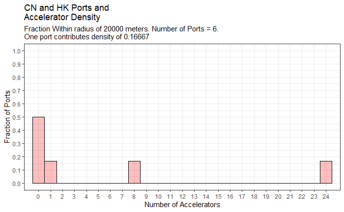

```r
p2
```

```r
# p1=ggplot() +
#   geom_histogram(aes(q), # , y=..density..
#                  color="black", fill="red2", alpha=.25,
#                  binwidth=1, boundary=-0.5) +
#   scale_x_continuous(breaks=1:min(n,r), minor_breaks=NULL) +
#   coord_cartesian(xlim=c(0,min(n,r)), ylim=c(0,r)) +
#   theme(panel.grid.minor.x = element_blank()) +
#   labs(x="Number of Accelerators", y="Number of Ports",
#        title=paste0("CN and HK",
#        " Ports and\nAccelerators Count"),
#        subtitle=paste0("Within radius of ",radius, " meters.",
#                        " Number of Ports = ", length(q), ".\n")) +
#   theme_bw()
#
# p2=ggplot() +
#   geom_histogram(aes(q, y=..density..), #
#                  color="black", fill="red2", alpha=.25,
#                  binwidth=1, boundary=-0.5) +
#   scale_x_continuous(breaks=1:min(n,r), minor_breaks=NULL) +
#   scale_y_continuous(n.breaks=10) +
#   coord_cartesian(xlim=c(0,min(n,r)), ylim=c(0,1)) +
#   theme(panel.grid.minor.x = element_blank()) +
#   labs(x="Number of Accelerators", y="Fraction of Ports",
#        title=paste0("CN and HK",
#        " Ports and \nAccelerator Density"),
#        subtitle=paste0("Fraction ","Within radius of ",radius, " meters.",
#                        " Number of Ports = ", length(q), ".\n",
#                        "One port contributes density of ",round(1/length(q),5))) +
#   theme_bw()
# p1
# p2
```

50% of CN and HK ports have no accelerator, another one, Dalian, have only one. Shanghai has 8 and Hongkong has 24.

### EU Ports

A histogram of European Union Ports.

Retrieve EU country codes and names.

```r
source("EUcountries.R")
EU_countries_df
```

| alpha2 | cname |
| --- | --- |
| AT | Austria |
| BE | Belgium |
| BG | Bulgaria |
| CY | Cyprus |
| CZ | Czechia |
| DE | Germany |
| DK | Denmark |
| EE | Estonia |
| ES | Spain |
| FI | Finland |

[output cut: 17 more lines]

```r
EU_alpha2s = EU_countries_df %>% pull(alpha2)
```

Set the country and extract the ports with counts.

```r
ctry=EU_alpha2s
b_f = ball_frame %>% filter(COUNTRY %in% ctry)
# glimpse(b_f)

xq=b_f %>% filter(is.na(Count))
# glimpse(xq)
if(nrow(xq)>0)
  xq %>% arrange(desc(Count)) else
    print(paste0("No ",ctry, " ports out of range."))
```

```
 [1] "No AT ports out of range." "No BE ports out of range." "No BG ports out of range."
 [4] "No CY ports out of range." "No CZ ports out of range." "No DE ports out of range."
 [7] "No DK ports out of range." "No EE ports out of range." "No ES ports out of range."
[10] "No FI ports out of range." "No FR ports out of range." "No GR ports out of range."
[13] "No HR ports out of range." "No HU ports out of range." "No IE ports out of range."
[16] "No IT ports out of range." "No LT ports out of range." "No LU ports out of range."
[19] "No LV ports out of range." "No MT ports out of range." "No NL ports out of range."
[22] "No PO ports out of range." "No PT ports out of range." "No RO ports out of range."
[25] "No SE ports out of range." "No SI ports out of range." "No SK ports out of range."
```

```r
yq=b_f %>% filter(!is.na(Count))
if(nrow(yq)>0)
  yq %>% arrange(desc(Count)) else
    print(paste0("No ",ctry, " ports in range."))
```

| PORT_NAME | INDEX_NO | COUNTRY | Count |
| --- | --- | --- | --- |
| BARCELONA | 38550 | ES | 25 |
| LISBOA | 37990 | PT | 20 |
| AMSTERDAM | 31060 | NL | 19 |
| KOBENHAVN | 29230 | DK | 10 |
| TALLINN | 28480 | EE | 9 |
| HAMBURG | 30780 | DE | 8 |
| HELSINKI | 28190 | FI | 8 |
| STOCKHOLM | 25380 | SE | 7 |
| PIRAIEVS | 42230 | GR | 5 |
| ROTTERDAM | 31140 | NL | 4 |

[output cut: 32 more lines]

Make histograms of count and fraction.

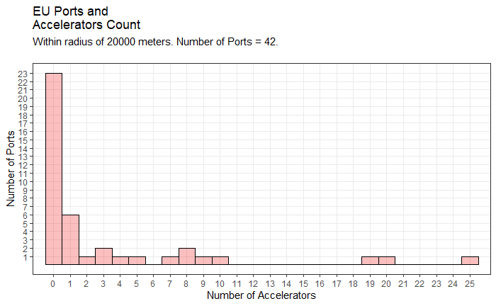

```r
# get largest count, usually at the 0 number of accelerators
h = yq %>% arrange(desc(Count)) %>% group_by(Count) %>%
  summarize(nlevel=n()) %>% pull(nlevel) %>% max()
# get largest number of Accelerators
n=max(b_f$Count)
# this parameter sets range of counts
r= max(yq$Count)

q=scales::oob_censor(b_f$Count, range=c(0,r))

p1=ggplot() +
  geom_histogram(aes(q), # , y=..density..
                 color="black", fill="red2", alpha=.25,
                 binwidth=1, boundary=-0.5) +
  scale_x_continuous(breaks=0:min(n,r), minor_breaks=NULL) +
  scale_y_continuous(breaks=1:h, minor_breaks=NULL) +
  coord_cartesian(xlim=c(0,min(n,r)), ylim=c(0,h)) +
  theme(panel.grid.minor.x = element_blank()) +
  labs(x="Number of Accelerators", y="Number of Ports",
       title=paste0("EU",
       " Ports and\nAccelerators Count"),
       subtitle=paste0("Within radius of ",radius, " meters.",
                       " Number of Ports = ", length(q), ".\n")) +
  theme_bw()

p2=ggplot() +
  geom_histogram(aes(q, y=..density..), #
                 color="black", fill="red2", alpha=.25,
                 binwidth=1, boundary=-0.5) +
  scale_x_continuous(breaks=0:min(n,r), minor_breaks=NULL) +
  scale_y_continuous(n.breaks=10) +
  coord_cartesian(xlim=c(0,min(n,r)), ylim=c(0,1)) +
  theme(panel.grid.minor.x = element_blank()) +
  labs(x="Number of Accelerators", y="Fraction of Ports",
       title=paste0("EU",
       " Ports and \nAccelerator Density"),
       subtitle=paste0("Fraction ","Within radius of ",radius, " meters.",
                       " Number of Ports = ", length(q), ".\n",
                       "One port contributes density of ",round(1/length(q),5))) +
  theme_bw()
p1
```

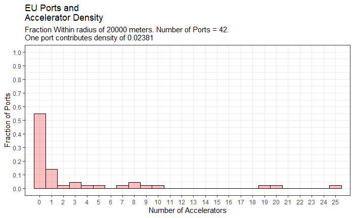

```r
p2
```

### ASEAN Countries

A histogram of ASEAN Ports.

Retrieve ASEAN country codes and names.

```r
ASEANcountries = c("Brunei", "Cambodia", "Indonesia", "Laos", "Malaysia", "Myanmar", "Philippines", "Singapore", "Thailand", "Vietnam")
ASEAN_alpha2s = countrycode::countryname(ASEANcountries, destination = "iso2c")
```

Set the country list and extract the ports with counts.

```r
ctry=ASEAN_alpha2s
b_f = ball_frame %>% filter(COUNTRY %in% ctry)
# glimpse(b_f)

xq=b_f %>% filter(is.na(Count))
# glimpse(xq)
if(nrow(xq)>0)
  xq %>% arrange(desc(Count)) else
    print(paste0("No ",ctry, " ports out of range."))
```

```
 [1] "No BN ports out of range." "No KH ports out of range." "No ID ports out of range."
 [4] "No LA ports out of range." "No MY ports out of range." "No MM ports out of range."
 [7] "No PH ports out of range." "No SG ports out of range." "No TH ports out of range."
[10] "No VN ports out of range."
```

```r
yq=b_f %>% filter(!is.na(Count))
if(nrow(yq)>0)
  yq %>% arrange(desc(Count)) else
    print(paste0("No ",ctry, " ports in range."))
```

| PORT_NAME | INDEX_NO | COUNTRY | Count |
| --- | --- | --- | --- |
| JOHOR | 49982 | MY | 43 |
| KEPPEL - (EAST SINGAPORE) | 50000 | SG | 43 |
| JURONG ISLAND | 50017 | SG | 43 |
| JAKARTA | 50970 | ID | 11 |
| MANILA | 58370 | PH | 4 |
| BANGKOK | 57450 | TH | 3 |
| KASIM TERMINAL | 53045 | ID | 0 |
| CEBU | 58960 | PH | 0 |
| CILACAP | 51220 | ID | 0 |
| TAPIS MARINE TERMINAL A | 57425 | MY | 0 |

[output cut: 1 more lines]

Johor, Keppel, and Jurong Island in or around Singapore have 43, Jakarta 11, Manila 4, and Bangkok 3, and the rest none.

Set plot parameters and draw histogram. Make histograms of count and fraction.

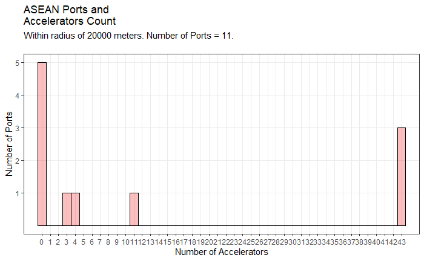

```r
# get largest count, usually at the 0 number of accelerators
h = yq %>% arrange(desc(Count)) %>% group_by(Count) %>%
  summarize(nlevel=n()) %>% pull(nlevel) %>% max()
# get largest number of Accelerators
n=max(b_f$Count)
# this parameter sets range of counts
r= max(yq$Count)

q=scales::oob_censor(b_f$Count, range=c(0,r))

p1=ggplot() +
  geom_histogram(aes(q), # , y=..density..
                 color="black", fill="red2", alpha=.25,
                 binwidth=1, boundary=-0.5) +
  scale_x_continuous(breaks=0:min(n,r), minor_breaks=NULL) +
  scale_y_continuous(breaks=1:h, minor_breaks=NULL) +
  coord_cartesian(xlim=c(0,min(n,r)), ylim=c(0,h)) +
  theme(panel.grid.minor.x = element_blank()) +
  labs(x="Number of Accelerators", y="Number of Ports",
       title=paste0("ASEAN",
       " Ports and\nAccelerators Count"),
       subtitle=paste0("Within radius of ",radius, " meters.",
                       " Number of Ports = ", length(q), ".\n")) +
  theme_bw()

p2=ggplot() +
  geom_histogram(aes(q, y=..density..), #
                 color="black", fill="red2", alpha=.25,
                 binwidth=1, boundary=-0.5) +
  scale_x_continuous(breaks=0:min(n,r), minor_breaks=NULL) +
  scale_y_continuous(n.breaks=10) +
  coord_cartesian(xlim=c(0,min(n,r)), ylim=c(0,1)) +
  theme(panel.grid.minor.x = element_blank()) +
  labs(x="Number of Accelerators", y="Fraction of Ports",
       title=paste0("ASEAN",
       " Ports and \nAccelerator Density"),
       subtitle=paste0("Fraction ","Within radius of ",radius, " meters.",
                       " Number of Ports = ", length(q), ".\n",
                       "One port contributes density of ",round(1/length(q),5))) +
  theme_bw()
p1
```

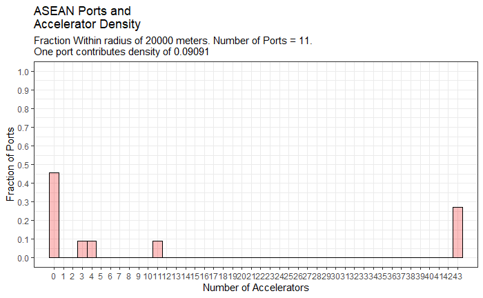

```r
p2
```

There is one cluster at Singapore.

### Northern East Asia Ports

A histogram of Northern East Asia Ports.

Retrieve Northern East Asia Ports country codes and names.

```r
NEAcountries = c("Japan", "Taiwan", "South Korea", "North Korea", "Philippines")
NEA_alpha2s = countrycode::countryname(NEAcountries, destination = "iso2c")
NEA_alpha2s
```

```
[1] "JP" "TW" "KR" "KP" "PH"
```

Set the country list and extract the ports with counts.

```r
ctry=NEA_alpha2s
b_f = ball_frame %>% filter(COUNTRY %in% ctry)
# glimpse(b_f)

xq=b_f %>% filter(is.na(Count))
# glimpse(xq)
if(nrow(xq)>0)
  xq %>% arrange(desc(Count)) else
    print(paste0("No ",ctry, " ports out of range."))
```

```
[1] "No JP ports out of range." "No TW ports out of range." "No KR ports out of range."
[4] "No KP ports out of range." "No PH ports out of range."
```

```r
yq=b_f %>% filter(!is.na(Count))
if(nrow(yq)>0)
  yq %>% arrange(desc(Count)) else
    print(paste0("No ",ctry, " ports in range."))
```

| PORT_NAME | INDEX_NO | COUNTRY | Count |
| --- | --- | --- | --- |
| TOKYO KO | 61380 | JP | 40 |
| KAWASAKI KO | 61385 | JP | 6 |
| MANILA | 58370 | PH | 4 |
| PUSAN | 60390 | KR | 1 |
| INCHON | 60320 | KR | 0 |
| CEBU | 58960 | PH | 0 |
| CHI-LUNG | 57890 | TW | 0 |
| NAGASAKI | 62360 | JP | 0 |
| WAKAMATSU KO | 62120 | JP | 0 |
| YOKOHAMA KO | 61390 | JP | 0 |

[output cut: 6 more lines]

Most are in Japan.

Set plot parameters and draw histogram. Make histograms of count and fraction.

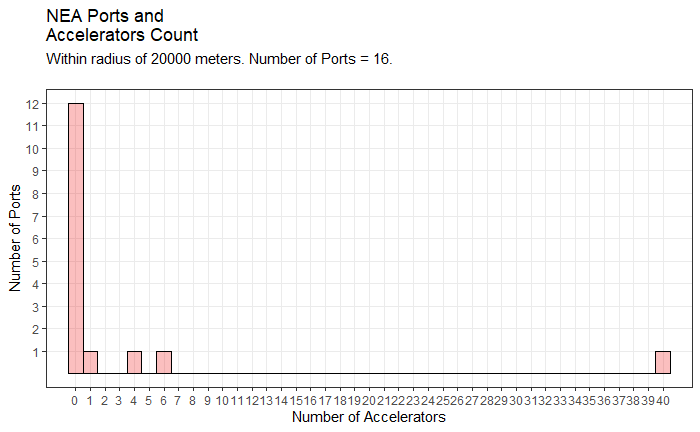

```r
# get largest count, usually at the 0 number of accelerators
h = yq %>% arrange(desc(Count)) %>% group_by(Count) %>%
  summarize(nlevel=n()) %>% pull(nlevel) %>% max()
# get largest number of Accelerators
n=max(b_f$Count)
# this parameter sets range of counts
r= max(yq$Count)

q=scales::oob_censor(b_f$Count, range=c(0,r))

p1=ggplot() +
  geom_histogram(aes(q), # , y=..density..
                 color="black", fill="red2", alpha=.25,
                 binwidth=1, boundary=-0.5) +
  scale_x_continuous(breaks=0:min(n,r), minor_breaks=NULL) +
  scale_y_continuous(breaks=1:h, minor_breaks=NULL) +
  coord_cartesian(xlim=c(0,min(n,r)), ylim=c(0,h)) +
  theme(panel.grid.minor.x = element_blank()) +
  labs(x="Number of Accelerators", y="Number of Ports",
       title=paste0("NEA",
       " Ports and\nAccelerators Count"),
       subtitle=paste0("Within radius of ",radius, " meters.",
                       " Number of Ports = ", length(q), ".\n")) +
  theme_bw()

p2=ggplot() +
  geom_histogram(aes(q, y=..density..), #
                 color="black", fill="red2", alpha=.25,
                 binwidth=1, boundary=-0.5) +
  scale_x_continuous(breaks=0:min(n,r), minor_breaks=NULL) +
  scale_y_continuous(n.breaks=10) +
  coord_cartesian(xlim=c(0,min(n,r)), ylim=c(0,1)) +
  theme(panel.grid.minor.x = element_blank()) +
  labs(x="Number of Accelerators", y="Fraction of Ports",
       title=paste0("NEA",
       " Ports and \nAccelerator Density"),
       subtitle=paste0("Fraction ","Within radius of ",radius, " meters.",
                       " Number of Ports = ", length(q), ".\n",
                       "One port contributes density of ",round(1/length(q),5))) +
  theme_bw()
p1
```

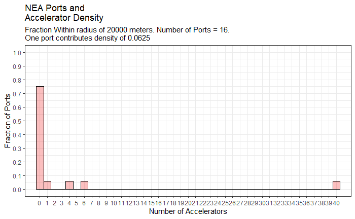

```r
p2
```

### Gulf Ports

```r
GULFcountries=c("Bahrain", "Kuwait", "Oman", "Qatar", "Saudi Arabia", "United Arab Emirates", "Iran", "Iraq", "Yemen")
GULF_alpha2s = countrycode::countryname(GULFcountries, destination = "iso2c")
GULF_alpha2s
```

```
[1] "BH" "KW" "OM" "QA" "SA" "AE" "IR" "IQ" "YE"
```

Set the country list and extract the ports with counts.

```r
ctry=GULF_alpha2s
b_f = ball_frame %>% filter(COUNTRY %in% ctry)
# glimpse(b_f)

xq=b_f %>% filter(is.na(Count))
# glimpse(xq)
if(nrow(xq)>0)
  xq %>% arrange(desc(Count)) else
    print(paste0("No ",ctry, " ports out of range."))
```

```
[1] "No BH ports out of range." "No KW ports out of range." "No OM ports out of range."
[4] "No QA ports out of range." "No SA ports out of range." "No AE ports out of range."
[7] "No IR ports out of range." "No IQ ports out of range." "No YE ports out of range."
```

```r
yq=b_f %>% filter(!is.na(Count))
if(nrow(yq)>0)
  yq %>% arrange(desc(Count)) else
    print(paste0("No ",ctry, " ports in range."))
```

| PORT_NAME | INDEX_NO | COUNTRY | Count |
| --- | --- | --- | --- |
| RAS ISA MARINE TERMINAL | 48155 | YE | 0 |
| MINA JABAL ALI | 48276 | AE | 0 |

Only two large ports are in this area, in Yemen and the UAE. Neither has nearby accelerators.

### Mediterranean Ports

```r
MEDcountries=c("Spain", "France", "Italy", "Greece", "Turkey", "Lebanon", "Israel", "Morocco", "Algeria","Tunisia","Libya","Egypt","Syria","Bulgaria","Serbia","Croatia","Slovenia")
MED_alpha2s = countrycode::countryname(MEDcountries, destination = "iso2c")
MED_alpha2s
```

```
 [1] "ES" "FR" "IT" "GR" "TR" "LB" "IL" "MA" "DZ" "TN" "LY" "EG" "SY" "BG" "RS" "HR" "SI"
```

Set the country list and extract the ports with counts.

```r
ctry=MED_alpha2s
b_f = ball_frame %>% filter(COUNTRY %in% ctry)
# glimpse(b_f)

xq=b_f %>% filter(is.na(Count))
# glimpse(xq)
if(nrow(xq)>0)
  xq %>% arrange(desc(Count)) else
    print(paste0("No ",ctry, " ports out of range."))
```

```
 [1] "No ES ports out of range." "No FR ports out of range." "No IT ports out of range."
 [4] "No GR ports out of range." "No TR ports out of range." "No LB ports out of range."
 [7] "No IL ports out of range." "No MA ports out of range." "No DZ ports out of range."
[10] "No TN ports out of range." "No LY ports out of range." "No EG ports out of range."
[13] "No SY ports out of range." "No BG ports out of range." "No RS ports out of range."
[16] "No HR ports out of range." "No SI ports out of range."
```

```r
yq=b_f %>% filter(!is.na(Count))
if(nrow(yq)>0)
  yq %>% arrange(desc(Count)) else
    print(paste0("No ",ctry, " ports in range."))
```

| PORT_NAME | INDEX_NO | COUNTRY | Count |
| --- | --- | --- | --- |
| BARCELONA | 38550 | ES | 25 |
| ISTANBUL | 43420 | TR | 15 |
| PIRAIEVS | 42230 | GR | 5 |
| BAYRUT | 45030 | LB | 4 |
| CASABLANCA | 45793 | MA | 3 |
| PORT OF ROUEN | 35850 | FR | 2 |
| AL ISKANDARIYH (ALEXANDRIA) | 45165 | EG | 2 |
| NAPOLI | 39960 | IT | 1 |
| TARRAGONA | 38540 | ES | 1 |
| IZMIR | 44750 | TR | 1 |

[output cut: 25 more lines]

Barcelona has 25 Accelerators, Istanbul 15, Piraeus 5, Beirut 4, Casablanca 3, Rouen 2 (not on the Mediterranean), and Alexandria 2. Three ports (Naples, Tarragona and Izmir) have 1 accelerator. All others have none.

Set plot parameters and draw histogram. Make histograms of count and fraction.

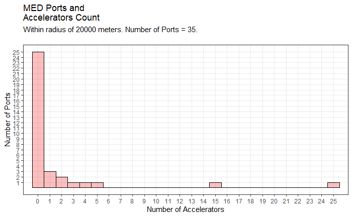

```r
# get largest count, usually at the 0 number of accelerators
h = yq %>% arrange(desc(Count)) %>% group_by(Count) %>%
  summarize(nlevel=n()) %>% pull(nlevel) %>% max()
# get largest number of Accelerators
n=max(b_f$Count)
# this parameter sets range of counts
r= max(yq$Count)

q=scales::oob_censor(b_f$Count, range=c(0,r))

p1=ggplot() +
  geom_histogram(aes(q), # , y=..density..
                 color="black", fill="red2", alpha=.25,
                 binwidth=1, boundary=-0.5) +
  scale_x_continuous(breaks=0:min(n,r), minor_breaks=NULL) +
  scale_y_continuous(breaks=1:h, minor_breaks=NULL) +
  coord_cartesian(xlim=c(0,min(n,r)), ylim=c(0,h)) +
  theme(panel.grid.minor.x = element_blank()) +
  labs(x="Number of Accelerators", y="Number of Ports",
       title=paste0("MED",
       " Ports and\nAccelerators Count"),
       subtitle=paste0("Within radius of ",radius, " meters.",
                       " Number of Ports = ", length(q), ".\n")) +
  theme_bw()

p2=ggplot() +
  geom_histogram(aes(q, y=..density..), #
                 color="black", fill="red2", alpha=.25,
                 binwidth=1, boundary=-0.5) +
  scale_x_continuous(breaks=0:min(n,r), minor_breaks=NULL) +
  scale_y_continuous(n.breaks=10) +
  coord_cartesian(xlim=c(0,min(n,r)), ylim=c(0,1)) +
  theme(panel.grid.minor.x = element_blank()) +
  labs(x="Number of Accelerators", y="Fraction of Ports",
       title=paste0("MED",
       " Ports and \nAccelerator Density"),
       subtitle=paste0("Fraction ","Within radius of ",radius, " meters.",
                       " Number of Ports = ", length(q), ".\n",
                       "One port contributes density of ",round(1/length(q),5))) +
  theme_bw()
p1
```

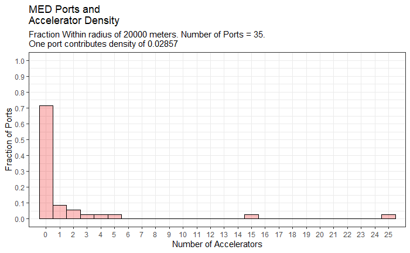

```r
p2
```

Over 70% of Ports have no Accelerator near.

### Indian Area Ports

Indian Area here includes states around the Indian ocean.

```r
INDcountries=c("India", "Pakistan", "Bangladesh", "Sri Lanka", "Myanmar", "Indonesia", "Somalia",
               "Thailand", "Kenya", "Tanzania")
IND_alpha2s = countrycode::countryname(INDcountries, destination = "iso2c")
IND_alpha2s
```

```
 [1] "IN" "PK" "BD" "LK" "MM" "ID" "SO" "TH" "KE" "TZ"
```

Set the country list and extract the ports with counts.

```r
ctry=IND_alpha2s
b_f = ball_frame %>% filter(COUNTRY %in% ctry)
# glimpse(b_f)

xq=b_f %>% filter(is.na(Count))
# glimpse(xq)
if(nrow(xq)>0)
  xq %>% arrange(desc(Count)) else
    print(paste0("No ",ctry, " ports out of range."))
```

```
 [1] "No IN ports out of range." "No PK ports out of range." "No BD ports out of range."
 [4] "No LK ports out of range." "No MM ports out of range." "No ID ports out of range."
 [7] "No SO ports out of range." "No TH ports out of range." "No KE ports out of range."
[10] "No TZ ports out of range."
```

```r
yq=b_f %>% filter(!is.na(Count))
if(nrow(yq)>0)
  yq %>% arrange(desc(Count)) else
    print(paste0("No ",ctry, " ports in range."))
```

| PORT_NAME | INDEX_NO | COUNTRY | Count |
| --- | --- | --- | --- |
| MUMBAI (BOMBAY) | 48840 | IN | 18 |
| JAKARTA | 50970 | ID | 11 |
| BANGKOK | 57450 | TH | 3 |
| CHENNAI (MADRAS) | 49450 | IN | 3 |
| CALCUTTA | 49560 | IN | 3 |
| KASIM TERMINAL | 53045 | ID | 0 |
| CILACAP | 51220 | ID | 0 |
| MUQDISHO | 47160 | SO | 0 |

Mumbai with 18 and Jakarta with 11 have large numbers of Accelerators. Bangkok, Chennai, and Calcutta each have 3. The rest have none.

Set plot parameters and draw histogram. Make histograms of count and fraction.

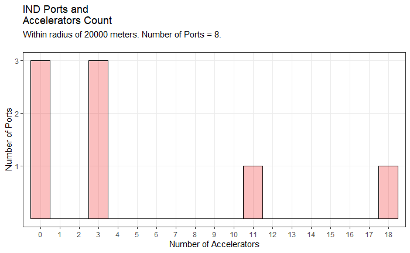

```r
# get largest count, usually at the 0 number of accelerators
h = yq %>% arrange(desc(Count)) %>% group_by(Count) %>%
  summarize(nlevel=n()) %>% pull(nlevel) %>% max()
# get largest number of Accelerators
n=max(b_f$Count)
# this parameter sets range of counts
r= max(yq$Count)

q=scales::oob_censor(b_f$Count, range=c(0,r))

p1=ggplot() +
  geom_histogram(aes(q), # , y=..density..
                 color="black", fill="red2", alpha=.25,
                 binwidth=1, boundary=-0.5) +
  scale_x_continuous(breaks=0:min(n,r), minor_breaks=NULL) +
  scale_y_continuous(breaks=1:h, minor_breaks=NULL) +
  coord_cartesian(xlim=c(0,min(n,r)), ylim=c(0,h)) +
  theme(panel.grid.minor.x = element_blank()) +
  labs(x="Number of Accelerators", y="Number of Ports",
       title=paste0("IND",
       " Ports and\nAccelerators Count"),
       subtitle=paste0("Within radius of ",radius, " meters.",
                       " Number of Ports = ", length(q), ".\n")) +
  theme_bw()

p2=ggplot() +
  geom_histogram(aes(q, y=..density..), #
                 color="black", fill="red2", alpha=.25,
                 binwidth=1, boundary=-0.5) +
  scale_x_continuous(breaks=0:min(n,r), minor_breaks=NULL) +
  scale_y_continuous(n.breaks=10) +
  coord_cartesian(xlim=c(0,min(n,r)), ylim=c(0,1)) +
  theme(panel.grid.minor.x = element_blank()) +
  labs(x="Number of Accelerators", y="Fraction of Ports",
       title=paste0("IND",
       " Ports and \nAccelerator Density"),
       subtitle=paste0("Fraction ","Within radius of ",radius, " meters.",
                       " Number of Ports = ", length(q), ".\n",
                       "One port contributes density of ",round(1/length(q),5))) +
  theme_bw()
p1
```

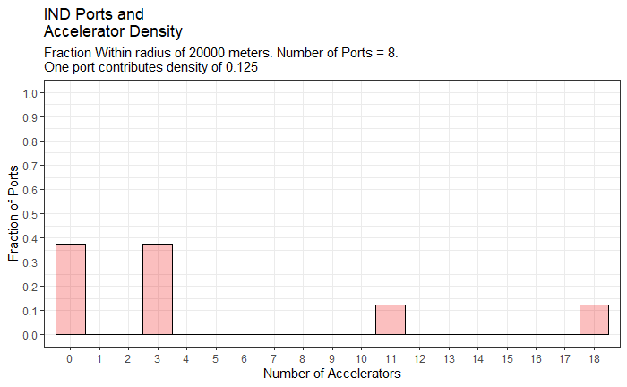

```r
p2
```

### South Pacific Ports

The area here includes states around the west Pacific ocean.

```r
ANZcountries=c("Australia", "New Zealand", "Guam")
ANZ_alpha2s = countrycode::countryname(ANZcountries, destination = "iso2c")
ANZ_alpha2s
```

```
[1] "AU" "NZ" "GU"
```

Set the country list and extract the ports with counts.

```r
ctry=ANZ_alpha2s
b_f = ball_frame %>% filter(COUNTRY %in% ctry)
# glimpse(b_f)

xq=b_f %>% filter(is.na(Count))
# glimpse(xq)
if(nrow(xq)>0)
  xq %>% arrange(desc(Count)) else
    print(paste0("No ",ctry, " ports out of range."))
```

```
[1] "No AU ports out of range." "No NZ ports out of range." "No GU ports out of range."
```

```r
yq=b_f %>% filter(!is.na(Count))
if(nrow(yq)>0)
  yq %>% arrange(desc(Count)) else
    print(paste0("No ",ctry, " ports in range."))
```

| PORT_NAME | INDEX_NO | COUNTRY | Count |
| --- | --- | --- | --- |
| SYDNEY | 53650 | AU | 30 |
| MELBOURNE | 54030 | AU | 12 |
| BRISBANE | 53490 | AU | 4 |
| WELLINGTON | 55150 | NZ | 3 |
| AUCKLAND | 55060 | NZ | 1 |
| FREMANTLE | 54520 | AU | 1 |
| NEWCASTLE | 53610 | AU | 0 |

Sydney with 30 and Melbourne with 12 have large numbers of Accelerators. Brisbane has 4, Wellington 3, and Auckland and Fremantle each have 1. The rest have none.

Set plot parameters and draw histogram. Make histograms of count and fraction.

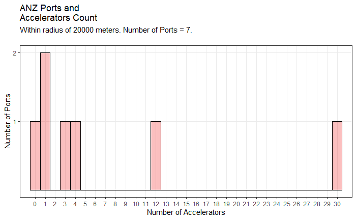

```r
# get largest count, usually at the 0 number of accelerators
h = yq %>% arrange(desc(Count)) %>% group_by(Count) %>%
  summarize(nlevel=n()) %>% pull(nlevel) %>% max()
# get largest number of Accelerators
n=max(b_f$Count)
# this parameter sets range of counts
r= max(yq$Count)

q=scales::oob_censor(b_f$Count, range=c(0,r))

p1=ggplot() +
  geom_histogram(aes(q), # , y=..density..
                 color="black", fill="red2", alpha=.25,
                 binwidth=1, boundary=-0.5) +
  scale_x_continuous(breaks=0:min(n,r), minor_breaks=NULL) +
  scale_y_continuous(breaks=1:h, minor_breaks=NULL) +
  coord_cartesian(xlim=c(0,min(n,r)), ylim=c(0,h)) +
  theme(panel.grid.minor.x = element_blank()) +
  labs(x="Number of Accelerators", y="Number of Ports",
       title=paste0("ANZ",
       " Ports and\nAccelerators Count"),
       subtitle=paste0("Within radius of ",radius, " meters.",
                       " Number of Ports = ", length(q), ".\n")) +
  theme_bw()

p2=ggplot() +
  geom_histogram(aes(q, y=..density..), #
                 color="black", fill="red2", alpha=.25,
                 binwidth=1, boundary=-0.5) +
  scale_x_continuous(breaks=0:min(n,r), minor_breaks=NULL) +
  scale_y_continuous(n.breaks=10) +
  coord_cartesian(xlim=c(0,min(n,r)), ylim=c(0,1)) +
  theme(panel.grid.minor.x = element_blank()) +
  labs(x="Number of Accelerators", y="Fraction of Ports",
       title=paste0("ANZ",
       " Ports and \nAccelerator Density"),
       subtitle=paste0("Fraction ","Within radius of ",radius, " meters.",
                       " Number of Ports = ", length(q), ".\n",
                       "One port contributes density of ",round(1/length(q),5))) +
  theme_bw()
p1
```

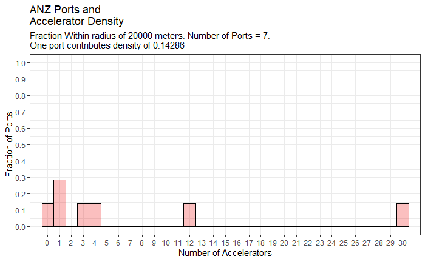

```r
p2
```

### South and Central American Ports

```r
SAMcountries=c("Mexico", "Panama", "Colombia","Cuba", "Haiti", "Dominican Republic",
               "Puerto Rico", "Bahamas", "Guadeloupe","Barbados", "Venezuela", "Guyana",
               "Peru", "Brazil", "Chile","Uruguay", "Argentina", "Falkland Islands",
               "Bermuda", "Trinidad and Tobago","Antigua", "Martinique", "Jamaica")
SAM_alpha2s = countrycode::countryname(SAMcountries, destination = "iso2c")
SAM_alpha2s
```

```
 [1] "MX" "PA" "CO" "CU" "HT" "DO" "PR" "BS" "GP" "BB" "VE" "GY" "PE" "BR" "CL" "UY" "AR" "FK"
[19] "BM" "TT" "AG" "MQ" "JM"
```

Set the country list and extract the ports with counts.

```r
ctry=SAM_alpha2s
b_f = ball_frame %>% filter(COUNTRY %in% ctry)
# glimpse(b_f)

xq=b_f %>% filter(is.na(Count))
# glimpse(xq)
if(nrow(xq)>0)
  xq %>% arrange(desc(Count)) else
    print(paste0("No ",ctry, " ports out of range."))
```

```
 [1] "No MX ports out of range." "No PA ports out of range." "No CO ports out of range."
 [4] "No CU ports out of range." "No HT ports out of range." "No DO ports out of range."
 [7] "No PR ports out of range." "No BS ports out of range." "No GP ports out of range."
[10] "No BB ports out of range." "No VE ports out of range." "No GY ports out of range."
[13] "No PE ports out of range." "No BR ports out of range." "No CL ports out of range."
[16] "No UY ports out of range." "No AR ports out of range." "No FK ports out of range."
[19] "No BM ports out of range." "No TT ports out of range." "No AG ports out of range."
[22] "No MQ ports out of range." "No JM ports out of range."
```

```r
yq=b_f %>% filter(!is.na(Count))
if(nrow(yq)>0)
  yq %>% arrange(desc(Count)) else
    print(paste0("No ",ctry, " ports in range."))
```

| PORT_NAME | INDEX_NO | COUNTRY | Count |
| --- | --- | --- | --- |
| BUENOS AIRES | 13760 | AR | 5 |
| RIO DE JANEIRO | 12920 | BR | 2 |
| TUBARAO | 12855 | BR | 1 |
| RIO GRANDE | 13060 | BR | 0 |
| SANTOS | 12970 | BR | 0 |
| PUERTO LA CRUZ | 12185 | VE | 0 |
| BAHIA DE SAGUA DE TANAMO | 10270 | CU | 0 |
| PUERTO GUANTANAMO | 10320 | CU | 0 |
| CIENFUEGOS | 10540 | CU | 0 |
| BAHAI DE LA HABANA | 10100 | CU | 0 |

[output cut: 2 more lines]

Buenos Aires Argentina has 5 Accelerators, Rio de Janiero,Brazil has 2, and Tubarao, Brazil has 1. None of the others have any Accelerators.

Set plot parameters and draw histogram. Make histograms of count and fraction.

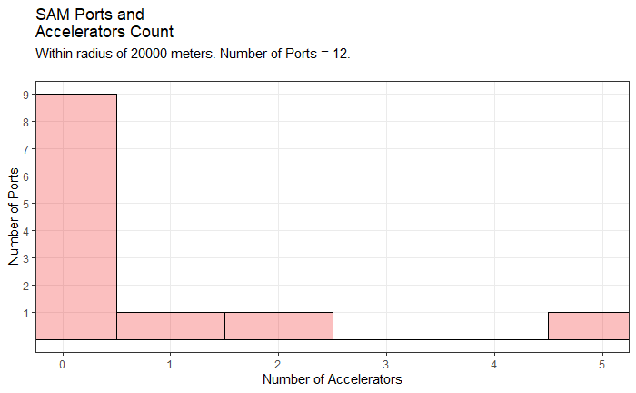

```r
# get largest count, usually at the 0 number of accelerators
h = yq %>% arrange(desc(Count)) %>% group_by(Count) %>%
  summarize(nlevel=n()) %>% pull(nlevel) %>% max()
# get largest number of Accelerators
n=max(b_f$Count)
# this parameter sets range of counts
r= max(yq$Count)

q=scales::oob_censor(b_f$Count, range=c(0,r))

p1=ggplot() +
  geom_histogram(aes(q), # , y=..density..
                 color="black", fill="red2", alpha=.25,
                 binwidth=1, boundary=-0.5) +
  scale_x_continuous(breaks=0:min(n,r), minor_breaks=NULL) +
  scale_y_continuous(breaks=1:h, minor_breaks=NULL) +
  coord_cartesian(xlim=c(0,min(n,r)), ylim=c(0,h)) +
  theme(panel.grid.minor.x = element_blank()) +
  labs(x="Number of Accelerators", y="Number of Ports",
       title=paste0("SAM",
       " Ports and\nAccelerators Count"),
       subtitle=paste0("Within radius of ",radius, " meters.",
                       " Number of Ports = ", length(q), ".\n")) +
  theme_bw()

p2=ggplot() +
  geom_histogram(aes(q, y=..density..), #
                 color="black", fill="red2", alpha=.25,
                 binwidth=1, boundary=-0.5) +
  scale_x_continuous(breaks=0:min(n,r), minor_breaks=NULL) +
  scale_y_continuous(n.breaks=10) +
  coord_cartesian(xlim=c(0,min(n,r)), ylim=c(0,1)) +
  theme(panel.grid.minor.x = element_blank()) +
  labs(x="Number of Accelerators", y="Fraction of Ports",
       title=paste0("SAM",
       " Ports and \nAccelerator Density"),
       subtitle=paste0("Fraction ","Within radius of ",radius, " meters.",
                       " Number of Ports = ", length(q), ".\n",
                       "One port contributes density of ",round(1/length(q),5))) +
  theme_bw()
p1
```

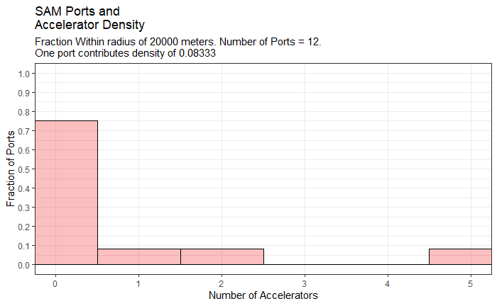

```r
p2
```

## Medium Size Ports

In this section we will analyze 20000 meter circles for ports with HARBORSIZE = “M” for medium size.

```r
wtarget=wpi_large %>% as.tibble %>% filter(HARBORSIZE=="M") %>%
  select(INDEX_NO, PORT_NAME, LONGITUDE, LATITUDE, COUNTRY)
wtarget %>% arrange(PORT_NAME)
```

There are 362 ports with Medium harborsize.

Now we find the Accelerators in a 20000 meter circle of each port.

```r
radius=20000
targets= c(1:nrow(wtarget))
ball_list=list()
ball_specs=list()
for (i in targets) {
  w=wtarget[i,]
  ans = purrr::map2_dfr(w$LONGITUDE, w$LATITUDE,
                         ~spatialrisk::points_in_circle(data=Accel_df3 , .x, .y,
                                                        lon, lat,
                                                        radius = radius))
  ans_count=nrow(ans)
  ball_list[w$PORT_NAME] = list(count=ans_count)
  if(ans_count>0) {
    # glimpse(ans)
    ans_short = ans %>% select(query, lon, lat, obs, name, distance_m)
    res = cbind(w, ans_short)
    # print(res)
    res_count = nrow(res)
    res_which = res$obs
    res_name = res$name
    res_port = w$PORT_NAME
    res_pindex = w$INDEX_NO
    ball_specs[w$PORT_NAME] = list(nearest=res)
  }
}
```

Find the accelerators inside the circle.

```r
length(wtarget$PORT_NAME)
length(ball_list)
length(ball_specs)
ball_frame = data.frame(Port=wtarget[targets,"PORT_NAME"],
                        PortID=wtarget[targets,"INDEX_NO"],
                        Country=wtarget[targets,"COUNTRY"],
                        Count=matrix(unlist(ball_list), nrow=length(wtarget$PORT_NAME), byrow=TRUE) #ball_list
                        )
ball_frame
ball_frame %>% arrange(desc(Count), PORT_NAME)
ball_frame %>% arrange(desc(Count), PORT_NAME) %>% group_by(Count) %>%
  summarize(number=n()) %>% arrange(desc(Count))

# ball_specs
```

```r
ctry=ball_frame$COUNTRY
b_f = ball_frame %>% filter(COUNTRY %in% ctry)
# glimpse(b_f)

xq=b_f %>% filter(is.na(Count))
# glimpse(xq)
if(nrow(xq)>0)
  xq %>% arrange(desc(Count)) else
    print(paste0("No ",ctry, " ports out of range."))
```

[output not shown]

[output cut: 106 more lines]

```r
yq=b_f %>% filter(!is.na(Count))
if(nrow(yq)>0)
  yq %>% arrange(desc(Count)) else
    print(paste0("No ",ctry, " ports in range."))
```

| PORT_NAME | INDEX_NO | COUNTRY | Count |
| --- | --- | --- | --- |
| ALBANY | 7720 | US | 123 |
| HOBOKEN | 7770 | US | 123 |
| JERSEY CITY | 7780 | US | 123 |
| STANLEY | 14000 | FK | 122 |
| BAYONNE | 7790 | US | 121 |
| PULAU BUKOM | 50010 | SG | 43 |
| CHICAGO | 4800 | US | 33 |
| INDIANA HARBOR | 4780 | US | 32 |
| TORONTO | 3000 | CA | 25 |
| AL MUKHA | 48175 | YE | 22 |

[output cut: 352 more lines]

Set plot parameters and draw histogram. Make histograms of count and fraction.

[figure not shown]

```r
# get largest count, usually at the 0 number of accelerators
h = yq %>% arrange(desc(Count)) %>% group_by(Count) %>%
  summarize(nlevel=n()) %>% pull(nlevel) %>% max()
# get largest number of Accelerators
n=max(b_f$Count)
# this parameter sets range of counts
r= 50 #max(yq$Count)

q=scales::oob_censor(b_f$Count, range=c(0,r))

p1=ggplot() +
  geom_histogram(aes(q), # , y=..density..
                 color="black", fill="red2", alpha=.25,
                 binwidth=1, boundary=-0.5) +
  scale_x_continuous(breaks=0:min(n,r), minor_breaks=NULL) +
  scale_y_continuous(breaks=1:h, minor_breaks=NULL) +
  coord_cartesian(xlim=c(0,min(n,r)), ylim=c(0,h)) +
  theme(panel.grid.minor.x = element_blank()) +
  labs(x="Number of Accelerators", y="Number of Ports",
       title=paste0("Medium Harborsize",
       " Ports and\nAccelerators Count"),
       subtitle=paste0("Within radius of ",radius, " meters.",
                       " Number of Ports = ", length(q), ".\n")) +
  theme_bw()

p2=ggplot() +
  geom_histogram(aes(q, y=..density..), #
                 color="black", fill="red2", alpha=.25,
                 binwidth=1, boundary=-.5) +
  scale_x_continuous(breaks=0:min(n,r), minor_breaks=NULL) +
  scale_y_continuous(n.breaks=10) +
  coord_cartesian(xlim=c(0,min(n,r)), ylim=c(0,1)) +
  theme(panel.grid.minor.x = element_blank()) +
  labs(x="Number of Accelerators", y="Fraction of Ports",
       title=paste0("Medium Harborsize",
       " Ports and \nAccelerator Density"),
       subtitle=paste0("Fraction ","Within radius of ",radius, " meters.",
                       " Number of Ports = ", length(q), ".\n",
                       "One port contributes density of ",round(1/length(q),5))) +
  theme_bw()
p1
```

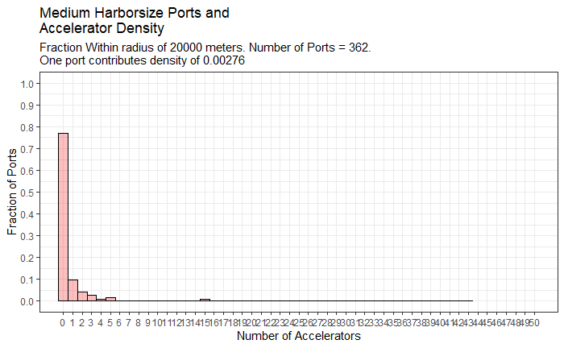

```r
p2
```

# End

```r
px=ggplot(x %>% filter(between(Year,2016,2021) )) +
  geom_col(aes(IndShort,TotVal, fill=Class), color="black", alpha=1) +
  scale_fill_manual(values = c("blue","yellow","red")) +
  theme(axis.text.x = element_text(angle = 60, vjust = 1, hjust=1)) +
  labs(title="Total Valuations by Industry and Year",
       x="Industry") +
  facet_wrap(vars(Year), ncol=2)
px
# ggsave("Valuations by Industry and Year.jpg", plot=px, device="jpeg", height=7 )
```

[output not shown]

### Count by Industry

```r
y = cbi_more %>% arrange(Year, Industry) %>% group_by(IndShort, Year, Class) %>% summarize(Count=n())
glimpse(y)
```

```r
py=ggplot(y %>% filter(between(Year,2016,2021) )) +
  geom_col(aes(IndShort,Count, fill=Class), color="black", alpha=1, orientation="x") +
  scale_fill_manual(values=c("blue","yellow","red")) +
  theme(axis.text.x = element_text(angle = 60, vjust = 1, hjust=1)) +
  labs(title="Count by Industry and Year") +
  facet_wrap(vars(Year), ncol=2)
py
# ggsave("Counts by Industry and Year.jpg", plot=py, device="jpeg", height=7 )
```

[output not shown]

## References

1. https://www.cbinsights.com/?utm_campaign=marketing_unicorns-list_2022-02
2. https://stackoverflow.com/questions/1735540/creating-a-pareto-chart-with-ggplot2-and-r
3. https://stats.stackexchange.com/questions/36212/what-tests-do-i-use-to-confirm-that-residuals-are-normally-distributed
4. https://stackoverflow.com/questions/31668163/geographic-geospatial-distance-between-2-lists-of-lat-lon-points-coordinates
5. https://msi.nga.mil/Publications/WPI